# Report

Advised by MicrobiomaLab

Diana H. Oaxaca

2024-04

# 1 Clean and remove adaptadors

Para limpiar y remover adaptadores se corrieron los siguientes scripts

```bash
#QC filter, delete nextera adapter and low quality
bash src/03.trimgalore.sh
#Remove adapters
bash src/05.cutadapt
```

# 2 Infer ASVs

Se infierieron las ASVs de cada corrida de secuenciación por separado con DADA2 en R

El código para cada corrida se encuentra en:

*2022* `src/Dada2_2022.html` *2023* `src/Dada2_2023.html`

# 3 Filter by frequence

## 3.1 Import outputs from DADA2 to QIIME2

```bash
    #Create output results dir
    mkdir -p results/02.QIIME2

#Import run 2022 files

    #import fasta seqs
    qiime tools import --input-path results/01.Dada2/2022/ASVs_2022.fasta --type 'FeatureData[Sequence]' --output-path results/02.QIIME2/ASV_rep_seq_2022.qza

    # append missing header to the table for import
    cat <(echo -n "#OTU Table") results/01.Dada2/2022/ASV_to_seqs-nochim_2022.tsv > results/02.QIIME2/temp.txt

    # convert to biom
    biom convert -i results/02.QIIME2/temp.txt -o results/02.QIIME2/temp.biom --table-type="OTU table" --to-hdf5

    #create feature table
    qiime tools import --input-path results/02.QIIME2/temp.biom --type 'FeatureTable[Frequency]' --input-format BIOMV210Format --output-path results/02.QIIME2/ASV_table_2022.qza

    #Get visual summarizes
    qiime feature-table tabulate-seqs \
    --i-data results/02.QIIME2/ASV_rep_seq_2022.qza \
    --o-visualization results/02.QIIME2/ASV_rep_seq_2022.qzv

    qiime feature-table summarize \
    --i-table results/02.QIIME2/ASV_table_2022.qza \
    --o-visualization results/02.QIIME2/ASV_table_2022.qzv

#Import run 2023 files

    #import fasta seqs
    qiime tools import --input-path results/01.Dada2/2023/ASVs_2023.fasta --type 'FeatureData[Sequence]' --output-path results/02.QIIME2/ASV_rep_seq_2023.qza

    # append missing header to the table for import
    cat <(echo -n "#OTU Table") results/01.Dada2/2023/ASV_to_seqs-nochim_2023.tsv > results/02.QIIME2/temp2.txt

    # convert to biom
    biom convert -i results/02.QIIME2/temp2.txt -o results/02.QIIME2/temp2.biom --table-type="OTU table" --to-hdf5

    #create feature table
    qiime tools import --input-path results/02.QIIME2/temp2.biom --type 'FeatureTable[Frequency]' --input-format BIOMV210Format --output-path results/02.QIIME2/ASV_table_2023.qza

    #Get visual summarizes
    qiime feature-table tabulate-seqs \
    --i-data results/02.QIIME2/ASV_rep_seq_2023.qza \
    --o-visualization results/02.QIIME2/ASV_rep_seq_2023.qzv

    qiime feature-table summarize \
    --i-table results/02.QIIME2/ASV_table_2023.qza \
    --o-visualization results/02.QIIME2/ASV_table_2023.qzv
```

## 3.2 Filter by frequence

```bash
# 2022
#Filter feature table by frequence
qiime feature-table filter-features --i-table  results/02.QIIME2/ASV_table_2022.qza --p-min-samples 1 --p-min-frequency 52 --o-filtered-table results/02.QIIME2/ASV_table_2022_freq52_1minsamp.qza

#Get visual feature table summary
qiime feature-table summarize --i-table results/02.QIIME2/ASV_table_2022_freq52_1minsamp.qza --o-visualization results/02.QIIME2/ASV_table_2022_freq52_1minsamp.qzv

#Filter rep-seqs 2022
qiime feature-table filter-seqs  --i-table results/02.QIIME2/ASV_table_2022_freq52_1minsamp.qza --i-data results/02.QIIME2/ASV_rep_seq_2022.qza --o-filtered-data results/02.QIIME2/ASV_rep_seq_2022_filter-freq52.qza

# 2023
#Filter feature table by frequence
qiime feature-table filter-features --i-table  results/02.QIIME2/ASV_table_2023.qza --p-min-samples 1 --p-min-frequency 97 --o-filtered-table results/02.QIIME2/ASV_table_2023_freq97_1minsamp.qza

#Get visual feature table summary
qiime feature-table summarize --i-table results/02.QIIME2/ASV_table_2023_freq97_1minsamp.qza --o-visualization results/02.QIIME2/ASV_table_2023_freq97_1minsamp.qzv

#Filter rep-seqs 2023
qiime feature-table filter-seqs  --i-table results/02.QIIME2/ASV_table_2023_freq97_1minsamp.qza --i-data results/02.QIIME2/ASV_rep_seq_2023.qza --o-filtered-data results/02.QIIME2/ASV_rep_seq_2023_filter-freq97.qza
```

# 4 Merge sequences and feature tables

> Inicialmente hice el merge sin filtrar por frecuencia

> ```
> #Merge rep seqs
> qiime feature-table merge-seqs  --i-data results/02.QIIME2/ASV_rep_seq_2022.qza results/02.QIIME2/ASV_rep_seq_2023.qza   --o-merged-data results/02.QIIME2/merged-rep_seqs.qza
>
> #Merge feature tables
> qiime feature-table merge --i-tables results/02.QIIME2/ASV_table_2022.qza results/02.QIIME2/ASV_table_2023.qza --p-overlap-method sum --o-merged-table results/02.QIIME2/merged-table.qza
>
> #Get visual summarizes
> qiime feature-table tabulate-seqs --i-data results/02.QIIME2/merged-rep_seqs.qza --o-visualization results/02.QIIME2/merged-rep_seqs.qzv
>
> qiime feature-table summarize --i-table results/02.QIIME2/merged-table.qza --o-visualization results/02.QIIME2/merged-table.qzv
>
>
> ## Merge by clustering
>
>
> #Explore how many ASVs are recovered if clustering
>
> #Cluster to 100 %
> qiime vsearch cluster-features-de-novo --p-threads 80 --i-table results/02.QIIME2/merged-table.qza --i-sequences results/02.QIIME2/merged-rep_seqs.qza --p-perc-identity 1 --o-clustered-table results/02.QIIME2/merged-table-dn-100.qza --o-clustered-sequences results/02.QIIME2/merged-rep-seqs-dn-100.qza
>
> qiime feature-table tabulate-seqs --i-data results/02.QIIME2/merged-rep-seqs-dn-100.qza --o-visualization results/02.QIIME2/merged-rep-seqs-dn-100.qzv
>
> qiime feature-table summarize --i-table results/02.QIIME2/merged-table-dn-100.qza --o-visualization results/02.QIIME2/merged-table-dn-100.qzv
>
> #Cluster to 99 %
> qiime vsearch cluster-features-de-novo --p-threads 80 --i-table results/02.QIIME2/merged-table.qza --i-sequences results/02.QIIME2/merged-rep_seqs.qza --p-perc-identity 0.99 --o-clustered-table results/02.QIIME2/merged-table-dn-99.qza --o-clustered-sequences results/02.QIIME2/merged-rep-seqs-dn-99.qza
>
> qiime feature-table tabulate-seqs --i-data results/02.QIIME2/merged-rep-seqs-dn-99.qza --o-visualization results/02.QIIME2/merged-rep-seqs-dn-99.qzv
> qiime feature-table summarize --i-table results/02.QIIME2/merged-table-dn-99.qza --o-visualization results/02.QIIME2/merged-table-dn-99.qzv
>
> ## Compare merge
>
> Cuando visualizo los ASVs inferidos en cada secuenciación y al juntar las tablas y secuencias tanto con el merge como con la clusterización, obtenemos los siguientes valores:
>
>
> | Type        | ASVs  | Frequency | Samples |
> | ----------- | ----- | --------- | ------- |
> | 2022        | 29302 | 2677260   | 53      |
> | 2023        | 19143 | 3035299   | 30      |
> | Merge       | 29302 | 5712559   | 83      |
> | Cluster-100 | 29300 | 5712559   | 83      |
> | Cluster-99  | 19449 | 5712559   | 83      |
>
> Entonces creo que lo adecuado es quedarme con el merge inicial
> ```

Después de hacer el merge, el clustering y la comparación creo que la opción adecuada es el merge simple. También considero que debo hacer el merge después de hacer el filtrado por frecuencia de cada corrida de secuenciación, pues al ser diferentes la frecuencia también lo es. Así que el merge final es el que se describe a continuación:

## 4.1 Merge

```bash
#Merge rep seqs
qiime feature-table merge-seqs  --i-data results/02.QIIME2/ASV_rep_seq_2022_filter-freq52.qza results/02.QIIME2/ASV_rep_seq_2023_filter-freq97.qza   --o-merged-data results/02.QIIME2/merged-rep_seqs_filters_freq52-97.qza

#Merge feature tables
qiime feature-table merge --i-tables results/02.QIIME2/ASV_table_2022_freq52_1minsamp.qza results/02.QIIME2/ASV_table_2023_freq97_1minsamp.qza --p-overlap-method sum --o-merged-table results/02.QIIME2/merged-table-filters-freq52-97.qza

#Get visual summarizes
qiime feature-table tabulate-seqs --i-data results/02.QIIME2/merged-rep_seqs_filters_freq52-97.qza --o-visualization results/02.QIIME2/merged-rep_seqs_filters_freq52-97.qzv

qiime feature-table summarize --i-table results/02.QIIME2/merged-table-filters-freq52-97.qza --o-visualization results/02.QIIME2/merged-table-filters-freq52-97.qzv
```

En la siguiente tabla se observan los ASVs obtenidos por corrida, antes y después de filtrar por frecuencia y también al hacer el merge de las corridas de secuenciación.

| Type | ASVs | Frequency | Samples |
| --- | --- | --- | --- |
| 2022 | 29302 | 2677260 | 53 |
| 2023 | 19143 | 3035299 | 30 |
| Merge | 29302 | 5712559 | 83 |
| Cluster-100 | 29300 | 5712559 | 83 |
| Cluster-99 | 19449 | 5712559 | 83 |
| 2022-filter-freq | 6316 | 2410664 | 53 |
| 2023-filter-freq | 2935 | 2754795 | 30 |
| Merge | 6316 | 5165459 | 83 |

# 5 Taxonomy assignment

```bash
#Tax classification
qiime feature-classifier classify-sklearn --i-classifier data/dbs/classifier_silva_138_trained.qza --i-reads results/02.QIIME2/merged-rep_seqs_filters_freq52-97.qza --o-classification results/02.QIIME2/taxonomy_merge.qza --p-n-jobs 80

#get visualization
qiime metadata tabulate --m-input-file results/02.QIIME2/taxonomy_merge.qza --o-visualization results/02.QIIME2/taxonomy_merge.qzv
```

# 6 Filter by taxonomy

```bash
qiime taxa filter-table --i-table results/02.QIIME2/merged-table-filters-freq52-97.qza --i-taxonomy results/02.QIIME2/taxonomy_merge.qza --p-exclude Archaea,Eukaryota,Mitochondria,Chloroplast --p-include p__ --o-filtered-table results/02.QIIME2/ASV_table_filter_freq_merge_aemc.qza

qiime feature-table summarize --i-table results/02.QIIME2/ASV_table_filter_freq_merge_aemc.qza --o-visualization results/02.QIIME2/ASV_table_filter_freq_merge_aemc.qzv
```

| Type | ASVs | Frequency | Samples |
| --- | --- | --- | --- |
| 2022 | 29302 | 2677260 | 53 |
| 2023 | 19143 | 3035299 | 30 |
| 2022-filter-freq | 6316 | 2410664 | 53 |
| 2023-filter-freq | 2935 | 2754795 | 30 |
| Merge-fltr-freq | 6316 | 5165459 | 83 |
| Mrg-fltr-freq-aemc | 6261 | 5084303 | 83 |

## 6.1 Remove in fasta seqs

```bash
#remove in fasta sequences
qiime feature-table filter-seqs  --i-table results/02.QIIME2/ASV_table_filter_freq_merge_aemc.qza --i-data results/02.QIIME2/merged-rep_seqs_filters_freq52-97.qza --o-filtered-data results/02.QIIME2/ASV_rep_seq_filters_freq_merge_aemc.qza
```

# 7 Phylogeny

```bash
nohup qiime phylogeny align-to-tree-mafft-iqtree \
--p-n-threads auto --i-sequences results/02.QIIME2/ASV_rep_seq_filters_freq_merge_aemc.qza \
--o-alignment results/02.QIIME2/align-mft-iqt.qza \
--o-masked-alignment results/02.QIIME2/masked-align-iqtree.qza \
--o-tree results/02.QIIME2/unrooted-tree-iqtree.qza \
--o-rooted-tree results/02.QIIME2/rooted-tree-iqtree.qza --verbose > outs/07.phylogeny-iqtree.nohup &
[1] 2166700
```

# 8 Get info per sample

```bash
#taxonomy
qiime tools export --input-path results/02.QIIME2/taxonomy_merge.qza --output-path results/02.QIIME2/exports/taxonomy

#feature table
qiime tools export --input-path results/02.QIIME2/ASV_table_filter_freq_merge_aemc.qza --output-path results/02.QIIME2/exports/ASV_table

#reformat taxonomy tsv
sed -i -e '1 s/Feature/#Feature/' -e '1 s/Taxon/taxonomy/' results/02.QIIME2/exports/taxonomy/taxonomy.tsv

#Add taxonomy to feature table
biom add-metadata -i results/02.QIIME2/exports/ASV_table/feature-table.biom -o results/02.QIIME2/exports/feature-table_tax.biom --observation-metadata-fp results/02.QIIME2/exports/taxonomy/taxonomy.tsv --sc-separated results/02.QIIME2/exports/taxonomy/taxonomy.tsv

#Convert to tsv from biom format
biom convert -i results/02.QIIME2/exports/feature-table_tax.biom -o results/02.QIIME2/exports/feature-table_tax.tsv --to-tsv --header-key taxonomy

#Get effective reads per sample
biom summarize-table -i results/02.QIIME2/exports/feature-table_tax.biom -o results/02.QIIME2/exports/feature-table_tax_reads_per_sample_summary.txt

#Get ASVs per sample
biom summarize-table -i results/02.QIIME2/exports/feature-table_tax.biom --qualitative -o results/02.QIIME2/exports/feature-table_tax_ASVs_per_sample_summary.txt
```

# 9 Diversity

```r
load("src/Diversity.RData")
```

```r
# load data
otu_table <- read_qza("results/02.QIIME2/ASV_table_filter_freq_merge_aemc.qza")$data
metadata <- read.delim("data/metadata.tsv", check.names = F)
```

## 9.1 Get Hill numbers

```r
# Get hill numbers
q0 <- hill_div(otu_table, qvalue = 0)
q1 <- hill_div(otu_table, qvalue = 1)
q2 <- hill_div(otu_table, qvalue = 2)

# Merge metadata with Hill numbers
q012_all <- cbind(q0, q1, q2) %>% as.data.frame() %>% rownames_to_column(var = "sample-id")
metadata_with_hill_all <- q012_all %>%
  inner_join(metadata, by = c("sample-id"="sample-id"))

metadata_with_hill_all %>% head() %>% kable()
```

| sample-id | q0 | q1 | q2 | sample | Source | Date | Year | Location | Week | Raw reads | Colect_number | Specimen | quant_reading | Effective_reads | ASVs |
| --- | --- | --- | --- | --- | --- | --- | --- | --- | --- | --- | --- | --- | --- | --- | --- |
| DR1014-E | 135 | 9.036873 | 3.171788 | DR1014-E | Stipe | sep-30 | 2021 | Monte obscuro Emiliano Zapata | 1 | 159896 | DRamos 1014 | Ind_1 | 948 | 68295 | 135 |
| DR1014-SAH | 2118 | 1145.961220 | 576.966109 | DR1014-SAH | Soil associated | sep-30 | 2021 | Monte obscuro Emiliano Zapata | 1 | 223804 | DRamos 1014 | Ind_1 | 3071 | 40974 | 2118 |
| DR1015-SAH | 2013 | 1017.330538 | 382.229265 | DR1015-SAH | Soil associated | sep-30 | 2021 | Monte obscuro Emiliano Zapata | 1 | 170670 | DRamos 1015 | Ind_2 | 3664 | 33175 | 2013 |
| DR1018-E | 768 | 47.874948 | 5.350837 | DR1018-E | Stipe | oct-07 | 2021 | Monte obscuro Emiliano Zapata | 2 | 68578 | DRamos 1018 | Ind_3 | 97 | 23890 | 768 |
| DR1018-SAH | 1824 | 887.566616 | 436.200764 | DR1018-SAH | Soil associated | oct-07 | 2021 | Monte obscuro Emiliano Zapata | 2 | 211120 | DRamos 1018 | Ind_3 | 4017 | 38161 | 1824 |
| DR1019-E | 1012 | 447.167799 | 145.072574 | DR1019-E | Stipe | oct-07 | 2021 | Monte obscuro Emiliano Zapata | 2 | 144270 | DRamos 1019 | Ind_4 | 215 | 33853 | 1012 |

```r
#save table
write.table(metadata_with_hill_all, "results/03.Diversity/Metadata_with_hill.tsv", quote = FALSE, sep = "\t", row.names = TRUE, col.names=TRUE)
```

## 9.2 Diversity with all samples

### 9.2.1 Explore Hill distribution

Antes de declarar el modelo hay que darle formato categórico a los factores:

```r
metadata_with_hill_all$Compartment <- factor(
  metadata_with_hill_all$Source,
  levels = c(
    "Soil associated",
    "Rhizhomorph",
    "Stipe"
    ),
  labels = c(
    "Soil associated",
    "Rhizhomorph",
    "Stipe"
  )
)
metadata_with_hill_all$Location <- factor(
  metadata_with_hill_all$Location,
  levels = c("Monte obscuro Emiliano Zapata", "El Castillo/Zentla", "Naolinco"),
  labels = c("Monte obscuro Emiliano Zapata", "El Castillo/Zentla", "Naolinco")
  )
```

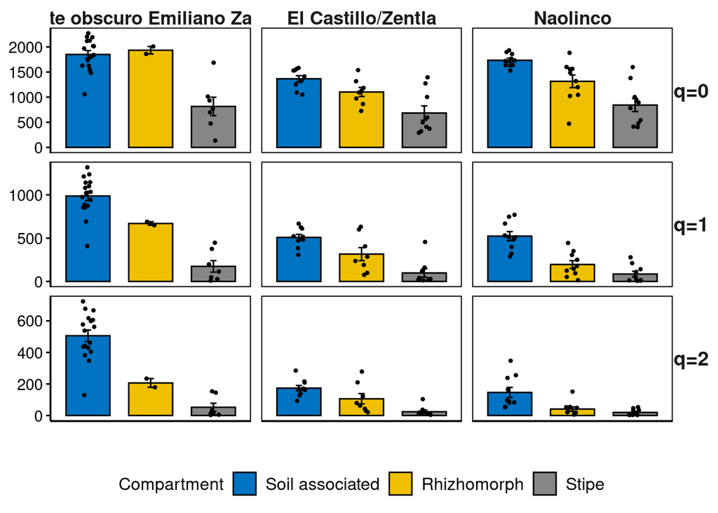

```r
library(ggpubr)

hill_barplot_explore_all <- metadata_with_hill_all %>%
  pivot_longer(cols = q0:q2, names_to = "q", values_to = "value") %>%
  filter(q %in% c("q0", "q1", "q2")) %>%
  mutate(
    qs = case_when(
      q == "q0" ~ "q=0",
      q == "q1" ~ "q=1",
      q == "q2" ~ "q=2"
    ),
    Location = factor(Location, levels = c("Monte obscuro Emiliano Zapata", "El Castillo/Zentla", "Naolinco"))
  ) %>%
  ggbarplot(
    x = "Compartment",
    y = "value",
    add = "mean_se",
    facet.by = c("qs", "Location"),
    fill = "Compartment"
  ) +
  scale_fill_jco() +
  geom_jitter(size = 0.8, position = position_jitter(width = 0.1)) +
  facet_grid(rows = vars(qs), cols = vars(Location), scales = "free_y") +
  theme(
    strip.background =  element_blank(), #element_rect(fill = "")
    strip.text.x = element_text(face= "bold", size = 13, margin = margin(0.5, 0, 0.5, 0)),
    strip.text.y = element_text(face= "bold", size = 14, angle = 0, margin = margin(0, 0.5, 0, 0.5)),
    axis.text.x = element_blank(),
    axis.ticks.x = element_blank(),
    axis.line = element_line(colour = "black"),
    #panel.border = element_blank(),
    panel.spacing.x = unit(0.5, "lines"),
    panel.background = element_blank(),
    axis.title.y = element_blank(),
    axis.text.y = element_text(colour = "black", size = 11),
    legend.position = "bottom"
  ) +
  labs(
    fill = "Compartment",
    y = "",
    x = "" #,
    #title = "Biodiversity across Locations and Compartments"
  ) + #+
  #theme(plot.title = element_text(hjust = 0.5))
   theme(legend.text = element_text(size = 12))

hill_barplot_explore_all
```

```r
ggsave("results/plots/02.diversity/01.all/01.Biodiversity_across_Locations and_Compartments.png", hill_barplot_explore_all, width = 11, height = 11)
```

### 9.2.2 Correlation Hill vs depth

**Alpha diversity depth correlation to order q=0**

```r
#install.packages("ggpubr")
library(ggpubr)

q0_vs_depth_all <- ggscatter(metadata_with_hill_all,
                         x = "Effective_reads",
                         y = "q0",
                         xlab= "Sequencing depth (number of reads)",
                         ylab = "q=0",
                         #ylab="Alpha diversity q=0 (effective number of total ASVs)",
   add = "reg.line",  # Add regression line
   add.params = list(color = "#114e9d", fill = "lightgray"), # Customize reg. line
   conf.int = TRUE, # Add confidence interval
   cor.coef = TRUE, # Add correlation coefficient. see ?stat_cor
   cor.coeff.args = list(method = "pearson", label.x = 3, label.sep = "\n")
   )+
  theme(legend.title = element_blank(), legend.position = "none")
```

**Alpha diversity depth correlation to order q=1**

```r
q1_vs_depth_all <- ggscatter(metadata_with_hill_all,
                         x = "Effective_reads",
                         y = "q1",
                         xlab= "Sequencing depth (number of reads)",
                         ylab = "q=1",
                         #ylab="Alpha diversity q=1 (effective number of total ASVs)",
   add = "reg.line",  # Add regression line
   add.params = list(color = "#114e9d", fill = "lightgray"), # Customize reg. line
   conf.int = TRUE, # Add confidence interval
   cor.coef = TRUE, # Add correlation coefficient. see ?stat_cor
   cor.coeff.args = list(method = "pearson", label.x = 3, label.sep = "\n")
   )+
  theme(legend.title = element_blank(), legend.position = "none")
```

**Alpha diversity depth correlation to order q=2**

```r
q2_vs_depth_all <- ggscatter(metadata_with_hill_all,
                         x = "Effective_reads",
                         y = "q2",
                         xlab= "Sequencing depth (number of reads)",
                         ylab = "q=2",
                         #ylab="Alpha diversity q=2 (effective number of total ASVs)",
   add = "reg.line",  # Add regression line
   add.params = list(color = "#114e9d", fill = "lightgray"), # Customize reg. line
   conf.int = TRUE, # Add confidence interval
   cor.coef = TRUE, # Add correlation coefficient. see ?stat_cor
   cor.coeff.args = list(method = "pearson", label.x = 3, label.sep = "\n")
   )+
  theme(legend.title = element_blank(), legend.position = "none")
```

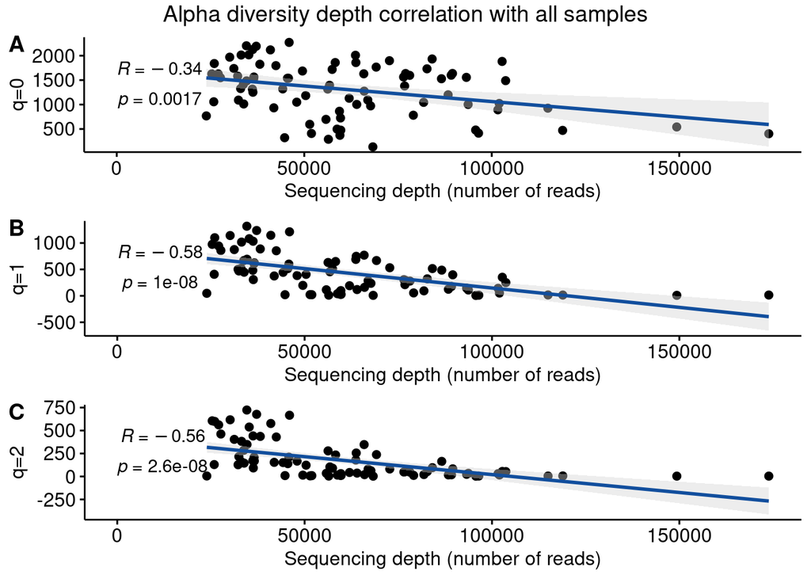

```r
library(ggplot2)
library(cowplot)
#save plots

#Combine plot
title_corr_plot <- ggdraw() + draw_label("Alpha diversity depth correlation with all samples")
correlation_plot_q012_all <- plot_grid(title_corr_plot, q0_vs_depth_all,q1_vs_depth_all,q2_vs_depth_all, labels = c(" ","A", "B", "C"), ncol = 1, rel_heights = c(0.15, 1, 1, 1))
correlation_plot_q012_all
```

```r
#save plot
ggsave("results/plots/02.diversity/01.all/02.alpha_depth_correlation_all_samples.png", correlation_plot_q012_all, width = 8, height = 8)
```

### 9.2.3 Shapiro test to Hill numbers

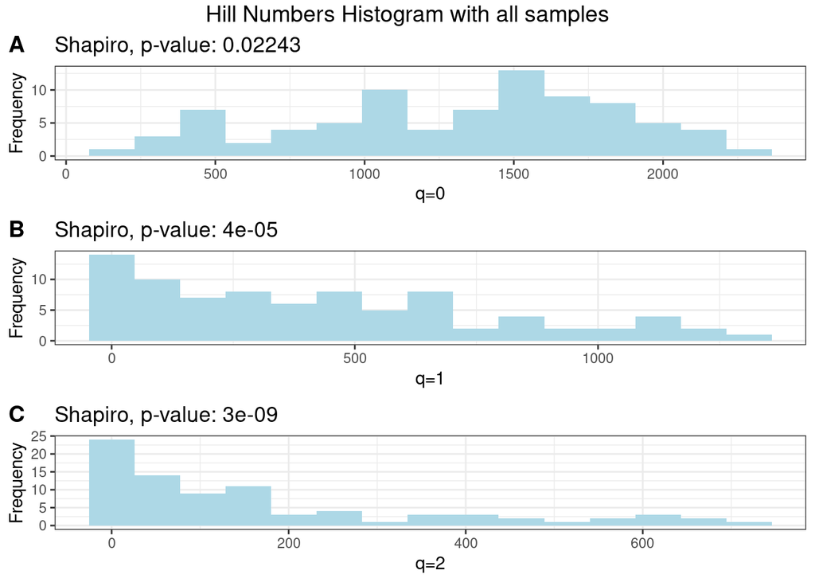

```r
library(ggplot2)
library(cowplot)

#Shapiro test
shapiro_q0_all <- shapiro.test(metadata_with_hill_all$q0)
shapiro_q0_all_pvalue <- round(shapiro_q0_all$p.value, 5)
shapiro_q1_all <- shapiro.test(metadata_with_hill_all$q1)
shapiro_q1_all_pvalue <- round(shapiro_q1_all$p.value, 5)
shapiro_q2_all <- shapiro.test(metadata_with_hill_all$q2)
shapiro_q2_all_pvalue <- round(shapiro_q2_all$p.value, 9)

#Histograms
histplot_q0_all <- ggplot(metadata_with_hill_all, aes(x = q0, xlab="q=0")) +
  geom_histogram(fill = "lightblue", bins = 15) +
  ggtitle(paste("Shapiro, p-value:", shapiro_q0_all_pvalue)) +
  theme_bw() + xlab("q=0") + ylab("Frequency")
histplot_q1_all <- ggplot(metadata_with_hill_all, aes(x = q1)) +
  geom_histogram(fill = "lightblue", bins = 15) +
  ggtitle(paste("Shapiro, p-value:", shapiro_q1_all_pvalue)) +
  theme_bw() + xlab("q=1") + ylab("Frequency")

histplot_q2_all <- ggplot(metadata_with_hill_all, aes(x = q2)) +
  geom_histogram(fill = "lightblue", bins = 15) +
  ggtitle(paste("Shapiro, p-value:", shapiro_q2_all_pvalue)) +
  theme_bw() + xlab("q=2") + ylab("Frequency")

#Combine plot
title_plot <- ggdraw() + draw_label("Hill Numbers Histogram with all samples") #, fontface = 'bold', x = 0.5, hjust = 0.5)
histplot_q012_all <- plot_grid(title_plot, histplot_q0_all, histplot_q1_all, histplot_q2_all, labels = c(" ","A", "B", "C"), ncol = 1, rel_heights = c(0.15, 1, 1, 1))
histplot_q012_all
```

```r
#save plot
ggsave("results/plots/02.diversity/01.all/03.hill_normality_test_histogram_all_samples.png", histplot_q012_all)
```

Ok, todos tienen una p < 0.05, por lo tanto se rechaza la Ho, es decir los datos no siguen distribución normal

### 9.2.4 Linear Models

Es la implementación básica para realizar regresiones lineales y se usa principalmente cuando las observaciones son independientes y homogéneas en varianza

- Análisis de regresión simple y múltiple.
- Casos donde las observaciones no están agrupadas o anidadas.
- Situaciones donde no hay necesidad de modelar variabilidad aleatoria en los interceptos o pendientes más allá del término de error usual.

Ahora aplicar el test de normalidad a los residuales del modelo

**lm**

```r
#  Source and Location interaction

#q0
lm_q0_SL_all <-lm(q0 ~ log(Effective_reads)+Source*Location, data = metadata_with_hill_all)
Shap_lm_q0_SL_all <- shapiro.test(lm_q0_SL_all$residuals)

#q1
lm_q1_SL_all<-lm(q1 ~ log(Effective_reads)+Source*Location, data = metadata_with_hill_all)
Shap_lm_q1_SL_all <- shapiro.test(lm_q1_SL_all$residuals)

#q2
lm_q2_SL_all<-lm(q2 ~ log(Effective_reads)+Source*Location, data = metadata_with_hill_all)
Shap_lm_q2_SL_all <- shapiro.test(lm_q2_SL_all$residuals)

#  Source

#q0
lm_q0_S_all <-lm(q0 ~ log(Effective_reads)+Source, data = metadata_with_hill_all)
Shap_lm_q0_S_all <- shapiro.test(lm_q0_S_all$residuals)

#q1
lm_q1_S_all <-lm(q1 ~ log(Effective_reads)+Source, data = metadata_with_hill_all)
Shap_lm_q1_S_all <- shapiro.test(lm_q1_S_all$residuals)

#q2
lm_q2_S_all <-lm(q2 ~ log(Effective_reads)+Source, data = metadata_with_hill_all)
Shap_lm_q2_S_all <- shapiro.test(lm_q2_S_all$residuals)

#  Location

#q0
lm_q0_L_all <-lm(q0 ~ log(Effective_reads)+Location, data = metadata_with_hill_all)
Shap_lm_q0_L_all <- shapiro.test(lm_q0_L_all$residuals)

#q1
lm_q1_L_all <-lm(q1 ~ log(Effective_reads)+Location, data = metadata_with_hill_all)
Shap_lm_q1_L_all <- shapiro.test(lm_q1_L_all$residuals)

#q2
lm_q2_L_all <-lm(q2 ~ log(Effective_reads)+Location, data = metadata_with_hill_all)
Shap_lm_q2_L_all <- shapiro.test(lm_q2_L_all$residuals)
```

```r
library(dplyr)
library(knitr)
library(kableExtra)
# p-values
ShapVal_lm_q012_all <- tibble(
  Metric = c("q0", "q1", "q2"),
  `Source-Location Interaction` = c(Shap_lm_q0_SL_all$p.value, Shap_lm_q1_SL_all$p.value, Shap_lm_q2_SL_all$p.value),
  Source = c(Shap_lm_q0_S_all$p.value, Shap_lm_q1_S_all$p.value, Shap_lm_q2_S_all$p.value),
  Location = c(Shap_lm_q0_L_all$p.value, Shap_lm_q1_L_all$p.value, Shap_lm_q2_L_all$p.value)
)

# table
kable(ShapVal_lm_q012_all,
      col.names = c("Hill", "Source*Location", "Source", "Location"),
      caption = "Residuals Shapiro-Wilk p-values for each Efect (lm)")
```

Residuals Shapiro-Wilk p-values for each Efect (lm)

| Hill | Source*Location | Source | Location |
| --- | --- | --- | --- |
| q0 | 0.4498458 | 0.7877501 | 0.0270996 |
| q1 | 0.0088939 | 0.6262767 | 0.1299597 |
| q2 | 0.0000082 | 0.0568286 | 0.0008822 |

```r
# save
write.csv(ShapVal_lm_q012_all, "results/03.Diversity/Residuals_Shapiro-Wilk_p-values_each_Efect(lm)_all.csv", row.names = FALSE)
```

### 9.2.5 Linear Mixed Models

Estos modelos son útiles cuando las observaciones tienen estructuras de dependencia, como datos longitudinales o datos agrupados/anidados. Los modelos lineales mixtos incluyen tanto efectos fijos como efectos aleatorios, donde los efectos fijos son comunes a todas las unidades/individuos, y los efectos aleatorios varían por grupo o unidad.

**lme**

```r
#library(nlme)
# lme

# q0
q0_lme_all <- lme(q0 ~ log(Effective_reads)+Source*Location, random=~1 |Specimen, data = metadata_with_hill_all)
q0_lme_perm_all <- PermTest(q0_lme_all, B = 100)

# q1
q1_lme_all <- lme(q1 ~ log(Effective_reads)+Source*Location, random=~1 |Specimen, data = metadata_with_hill_all)
q1_lme_perm_all <- PermTest(q1_lme_all, B = 100)

# q2
q2_lme_all <- lme(q2 ~ log(Effective_reads)+Source*Location, random=~1 |Specimen, data = metadata_with_hill_all)
q2_lme_perm_all <- PermTest(q2_lme_all, B = 100)
```

```r
# extract p-values fun
extract_pvalues <- function(perm_test_result) {
  perm_test_result$resultats$p.value
}

# extract
lme_pvalues_q0_all <- extract_pvalues(q0_lme_perm_all)
lme_pvalues_q1_all <- extract_pvalues(q1_lme_perm_all)
lme_pvalues_q2_all <- extract_pvalues(q2_lme_perm_all)

# Dataframe  p-values
library(dplyr)

lme_pvalues_table_all <- data.frame(
  Hill = c("q0", "q1", "q2"),
  `Intercept` = c(lme_pvalues_q0_all[1], lme_pvalues_q1_all[1], lme_pvalues_q2_all[1]),
  `log(Depth)` = c(lme_pvalues_q0_all[2], lme_pvalues_q1_all[2], lme_pvalues_q2_all[2]),
  `Source` = c(lme_pvalues_q0_all[3], lme_pvalues_q1_all[3], lme_pvalues_q2_all[3]),
  `Location` = c(lme_pvalues_q0_all[4], lme_pvalues_q1_all[4], lme_pvalues_q2_all[4]),
  `Source:Location` = c(lme_pvalues_q0_all[5], lme_pvalues_q1_all[5], lme_pvalues_q2_all[5])
)

# table
knitr::kable(t(lme_pvalues_table_all), caption = "P-values from Permuted LME")
```

P-values from Permuted LME

| Hill | q0 | q1 | q2 |
| --- | --- | --- | --- |
| Intercept | 0.18 | 0.00 | 0.02 |
| log.Depth. | 0.51 | 0.01 | 0.07 |
| Source | 0 | 0 | 0 |
| Location | 0.01 | 0.03 | 0.27 |
| Source.Location | 0.07 | 0.00 | 0.00 |

```r
# save
write.csv(t(lme_pvalues_table_all), "results/03.Diversity/P-values_from_Permuted_LME_all.csv", row.names = FALSE)
```

### 9.2.6 Generalized Linear Mixed Models

Ahora con modelos generalizados:

**glm**

```r
summary(q0_glm_all)
```

```
##
## Call:
## glm(formula = q0 ~ log(Effective_reads) + Source * Location,
##     family = poisson(link = "log"), data = metadata_with_hill_all)
##
## Deviance Residuals:
##      Min        1Q    Median        3Q       Max
## -28.1596   -7.1401    0.3118    5.2998   27.1088
##
## Coefficients:
##                                                  Estimate Std. Error z value
## (Intercept)                                       9.19982    0.17619  52.215
## log(Effective_reads)                             -0.14820    0.01593  -9.306
## SourceSoil associated                            -0.13486    0.01965  -6.864
## SourceStipe                                      -0.90917    0.02143 -42.428
## LocationEl Castillo/Zentla                       -0.56864    0.01930 -29.460
## LocationNaolinco                                 -0.33259    0.01914 -17.381
## SourceSoil associated:LocationEl Castillo/Zentla  0.28081    0.02198  12.776
## SourceStipe:LocationEl Castillo/Zentla            0.42717    0.02702  15.808
## SourceSoil associated:LocationNaolinco            0.38712    0.02184  17.727
## SourceStipe:LocationNaolinco                      0.48648    0.02618  18.586
##                                                  Pr(>|z|)
## (Intercept)                                       < 2e-16 ***
## log(Effective_reads)                              < 2e-16 ***
## SourceSoil associated                            6.67e-12 ***
## SourceStipe                                       < 2e-16 ***
## LocationEl Castillo/Zentla                        < 2e-16 ***
## LocationNaolinco                                  < 2e-16 ***
## SourceSoil associated:LocationEl Castillo/Zentla  < 2e-16 ***
## SourceStipe:LocationEl Castillo/Zentla            < 2e-16 ***
## SourceSoil associated:LocationNaolinco            < 2e-16 ***
## SourceStipe:LocationNaolinco                      < 2e-16 ***
## ---
## Signif. codes:  0 '***' 0.001 '**' 0.01 '*' 0.05 '.' 0.1 ' ' 1
##
## (Dispersion parameter for poisson family taken to be 1)
##
##     Null deviance: 20581.6  on 82  degrees of freedom
## Residual deviance:  8394.8  on 73  degrees of freedom
## AIC: 9152.9
##
## Number of Fisher Scoring iterations: 4
```

**glm quasipoisson**

```r
#q0 glm quasipoisson
q0_glm_quasipoisson_all <- glm(q0 ~ log(Effective_reads)+Source*Location,
              family = quasipoisson(link = "log"),
              data = metadata_with_hill_all)

#q1 glm quasipoisson
q1_glm_quasipoisson_all <- glm(q1 ~ log(Effective_reads)+Source*Location,
              family = quasipoisson(link = "log"),
              data = metadata_with_hill_all)

#q2 glm quasipoisson
q2_glm_quasipoisson_all <- glm(q1 ~ log(Effective_reads)+Source*Location,
              family = quasipoisson(link = "log"),
              data = metadata_with_hill_all)
```

```r
summary(q0_glm_quasipoisson_all)
```

```
##
## Call:
## glm(formula = q0 ~ log(Effective_reads) + Source * Location,
##     family = quasipoisson(link = "log"), data = metadata_with_hill_all)
##
## Deviance Residuals:
##      Min        1Q    Median        3Q       Max
## -28.1596   -7.1401    0.3118    5.2998   27.1088
##
## Coefficients:
##                                                  Estimate Std. Error t value
## (Intercept)                                        9.1998     1.8811   4.891
## log(Effective_reads)                              -0.1482     0.1700  -0.872
## SourceSoil associated                             -0.1349     0.2098  -0.643
## SourceStipe                                       -0.9092     0.2288  -3.974
## LocationEl Castillo/Zentla                        -0.5686     0.2061  -2.759
## LocationNaolinco                                  -0.3326     0.2043  -1.628
## SourceSoil associated:LocationEl Castillo/Zentla   0.2808     0.2347   1.197
## SourceStipe:LocationEl Castillo/Zentla             0.4272     0.2885   1.481
## SourceSoil associated:LocationNaolinco             0.3871     0.2331   1.660
## SourceStipe:LocationNaolinco                       0.4865     0.2795   1.741
##                                                  Pr(>|t|)
## (Intercept)                                      5.81e-06 ***
## log(Effective_reads)                             0.386288
## SourceSoil associated                            0.522270
## SourceStipe                                      0.000164 ***
## LocationEl Castillo/Zentla                       0.007317 **
## LocationNaolinco                                 0.107848
## SourceSoil associated:LocationEl Castillo/Zentla 0.235321
## SourceStipe:LocationEl Castillo/Zentla           0.143004
## SourceSoil associated:LocationNaolinco           0.101121
## SourceStipe:LocationNaolinco                     0.085932 .
## ---
## Signif. codes:  0 '***' 0.001 '**' 0.01 '*' 0.05 '.' 0.1 ' ' 1
##
## (Dispersion parameter for quasipoisson family taken to be 113.9871)
##
##     Null deviance: 20581.6  on 82  degrees of freedom
## Residual deviance:  8394.8  on 73  degrees of freedom
## AIC: NA
##
## Number of Fisher Scoring iterations: 4
```

**glmer**

```r
#q0 glmer
q0_glmer_all <- glmer(q0 ~ log(Effective_reads)+Source*Location+(1|Specimen),
             family = poisson(link = "log"),
             data = metadata_with_hill_all)

#q1 glmer
q1_glmer_all <- glmer(q1 ~ log(Effective_reads)+Source*Location+(1|Specimen),
             family = poisson(link = "log"),
             data = metadata_with_hill_all)

#q2 glmer
q2_glmer_all <- glmer(q2 ~ log(Effective_reads)+Source*Location+(1|Specimen),
             family = poisson(link = "log"),
             data = metadata_with_hill_all)
```

```r
summary(q0_glmer_all)
```

```
## Generalized linear mixed model fit by maximum likelihood (Laplace
##   Approximation) [glmerMod]
##  Family: poisson  ( log )
## Formula: q0 ~ log(Effective_reads) + Source * Location + (1 | Specimen)
##    Data: metadata_with_hill_all
##
##      AIC      BIC   logLik deviance df.resid
##   5261.1   5287.7  -2619.5   5239.1       72
##
## Scaled residuals:
##     Min      1Q  Median      3Q     Max
## -18.742  -4.663  -0.041   3.409  22.755
##
## Random effects:
##  Groups   Name        Variance Std.Dev.
##  Specimen (Intercept) 0.04448  0.2109
## Number of obs: 83, groups:  Specimen, 36
##
## Fixed effects:
##                                                  Estimate Std. Error z value
## (Intercept)                                      10.20320    0.25445  40.100
## log(Effective_reads)                             -0.26813    0.02283 -11.745
## SourceSoil associated                             0.09774    0.02306   4.238
## SourceStipe                                      -0.80115    0.02410 -33.247
## LocationEl Castillo/Zentla                       -0.31971    0.08814  -3.627
## LocationNaolinco                                  0.01303    0.08857   0.147
## SourceSoil associated:LocationEl Castillo/Zentla  0.03229    0.02498   1.293
## SourceStipe:LocationEl Castillo/Zentla            0.35025    0.02938  11.920
## SourceSoil associated:LocationNaolinco            0.13627    0.02460   5.540
## SourceStipe:LocationNaolinco                      0.38755    0.02860  13.550
##                                                  Pr(>|z|)
## (Intercept)                                       < 2e-16 ***
## log(Effective_reads)                              < 2e-16 ***
## SourceSoil associated                            2.25e-05 ***
## SourceStipe                                       < 2e-16 ***
## LocationEl Castillo/Zentla                       0.000286 ***
## LocationNaolinco                                 0.883020
## SourceSoil associated:LocationEl Castillo/Zentla 0.196091
## SourceStipe:LocationEl Castillo/Zentla            < 2e-16 ***
## SourceSoil associated:LocationNaolinco           3.03e-08 ***
## SourceStipe:LocationNaolinco                      < 2e-16 ***
## ---
## Signif. codes:  0 '***' 0.001 '**' 0.01 '*' 0.05 '.' 0.1 ' ' 1
##
## Correlation of Fixed Effects:
##             (Intr) lg(E_) SrcSla SrcStp LcEC/Z LctnNl SSa:LC SS:LEC SSa:LN
## lg(Effctv_) -0.975
## SrcSlassctd -0.504  0.448
## SourceStipe -0.326  0.273  0.769
## LctnECstl/Z -0.122 -0.020  0.187  0.165
## LocatinNlnc -0.014 -0.131  0.137  0.134  0.411
## SrcSa:LEC/Z  0.074 -0.011 -0.743 -0.600 -0.239 -0.179
## SrcSt:LEC/Z  0.271 -0.228 -0.632 -0.821 -0.182 -0.109  0.654
## SrcSassc:LN  0.332 -0.276 -0.873 -0.682 -0.178 -0.182  0.695  0.560
## SrcStp:LctN  0.365 -0.324 -0.690 -0.868 -0.137 -0.131  0.507  0.713  0.708
## optimizer (Nelder_Mead) convergence code: 0 (OK)
## Model failed to converge with max|grad| = 0.00219432 (tol = 0.002, component 1)
```

**glmmTMB**

```r
# glmmTMB
# q0
q0_glmmTMB_all <- glmmTMB(q0 ~ log(Effective_reads)+Source*Location + (1 | Specimen),
    family = poisson(link = "log"),
    data = metadata_with_hill_all,
    dispformula = ~ 1)  # Establecer la fórmula de la sobredispersión

# q1
q1_glmmTMB_all <- glmmTMB(q1 ~ log(Effective_reads)+Source*Location + (1 | Specimen),
    family = poisson(link = "log"),
    data = metadata_with_hill_all,
    dispformula = ~ 1)
# q2
q2_glmmTMB_all <- glmmTMB(q2 ~ log(Effective_reads)+Source*Location + (1 | Specimen),
    family = poisson(link = "log"),
    data = metadata_with_hill_all,
    dispformula = ~ 1)
summary(q0_glmmTMB_all)
```

```
##  Family: poisson  ( log )
## Formula:
## q0 ~ log(Effective_reads) + Source * Location + (1 | Specimen)
## Data: metadata_with_hill_all
##
##      AIC      BIC   logLik deviance df.resid
##   5261.1   5287.7  -2619.5   5239.1       72
##
## Random effects:
##
## Conditional model:
##  Groups   Name        Variance Std.Dev.
##  Specimen (Intercept) 0.04448  0.2109
## Number of obs: 83, groups:  Specimen, 36
##
## Conditional model:
##                                                  Estimate Std. Error z value
## (Intercept)                                      10.20320    0.25446   40.10
## log(Effective_reads)                             -0.26813    0.02283  -11.74
## SourceSoil associated                             0.09774    0.02306    4.24
## SourceStipe                                      -0.80114    0.02410  -33.24
## LocationEl Castillo/Zentla                       -0.31971    0.08814   -3.63
## LocationNaolinco                                  0.01303    0.08857    0.15
## SourceSoil associated:LocationEl Castillo/Zentla  0.03229    0.02498    1.29
## SourceStipe:LocationEl Castillo/Zentla            0.35024    0.02939   11.92
## SourceSoil associated:LocationNaolinco            0.13627    0.02460    5.54
## SourceStipe:LocationNaolinco                      0.38755    0.02860   13.55
##                                                  Pr(>|z|)
## (Intercept)                                       < 2e-16 ***
## log(Effective_reads)                              < 2e-16 ***
## SourceSoil associated                            2.26e-05 ***
## SourceStipe                                       < 2e-16 ***
## LocationEl Castillo/Zentla                       0.000286 ***
## LocationNaolinco                                 0.883049
## SourceSoil associated:LocationEl Castillo/Zentla 0.196127
## SourceStipe:LocationEl Castillo/Zentla            < 2e-16 ***
## SourceSoil associated:LocationNaolinco           3.04e-08 ***
## SourceStipe:LocationNaolinco                      < 2e-16 ***
## ---
## Signif. codes:  0 '***' 0.001 '**' 0.01 '*' 0.05 '.' 0.1 ' ' 1
```

**Verificar ajuste de varios modelos**

```r
q012_gmodels_comparison_all <- data.frame(
  Model = c("GLM Poisson q0", "GLM Quasi-Poisson q0", "GLMM Poisson q0", "GLMM Poisson TMB q0",
            "GLM Poisson q1", "GLM Quasi-Poisson q1", "GLMM Poisson q1", "GLMM Poisson TMB q1",
            "GLM Poisson q2", "GLM Quasi-Poisson q2", "GLMM Poisson q2", "GLMM Poisson TMB q2"),
  AIC = c(AIC(q0_glm_all), calculate_AIC_quasiPoisson(q0_glm_quasipoisson_all), AIC(q0_glmer_all), AIC(q0_glmmTMB_all),
          AIC(q1_glm_all), calculate_AIC_quasiPoisson(q1_glm_quasipoisson_all), AIC(q1_glmer_all), AIC(q1_glmmTMB_all),
          AIC(q2_glm_all), calculate_AIC_quasiPoisson(q2_glm_quasipoisson_all), AIC(q2_glmer_all), AIC(q2_glmmTMB_all)),
  BIC = c(BIC(q0_glm_all), BIC(q0_glm_quasipoisson_all), BIC(q0_glmer_all), BIC(q0_glmmTMB_all),
          BIC(q1_glm_all), BIC(q1_glm_quasipoisson_all), BIC(q1_glmer_all), BIC(q1_glmmTMB_all),
          BIC(q2_glm_all), BIC(q2_glm_quasipoisson_all), BIC(q2_glmer_all), BIC(q2_glmmTMB_all)),
  Null_Deviance = c(q0_glm_all$null.deviance, q0_glm_quasipoisson_all$null.deviance, NA, NA,
                    q1_glm_all$null.deviance, q1_glm_quasipoisson_all$null.deviance, NA, NA,
                    q2_glm_all$null.deviance, q2_glm_quasipoisson_all$null.deviance, NA, NA),
  Residual_Deviance = c(q0_glm_all$deviance, q0_glm_quasipoisson_all$deviance, summary(q0_glmer_all)$deviance, summary(q0_glmmTMB_all)$deviance,
                        q1_glm_all$deviance, q1_glm_quasipoisson_all$deviance, summary(q1_glmer_all)$deviance, summary(q1_glmmTMB_all)$deviance,
                        q2_glm_all$deviance, q2_glm_quasipoisson_all$deviance, summary(q2_glmer_all)$deviance, summary(q2_glmmTMB_all)$deviance)
)
# show
print(q012_gmodels_comparison_all)
```

[output not shown]

```r
library(MuMIn)
library(kableExtra)

# Compare models
q012_model_selection_all <- model.sel(q0_glm_all, q0_glm_quasipoisson_all,
                                    q0_glmer_all, q0_glmmTMB_all,
                                    q1_glm_all, q1_glm_quasipoisson_all,
                                    q1_glmer_all, q1_glmmTMB_all,
                                    q2_glm_all, q2_glm_quasipoisson_all,
                                    q2_glmer_all, q2_glmmTMB_all)
# table
kable(q012_model_selection_all, format = "html") %>%
  kable_styling(bootstrap_options = c("striped", "hover"))
```

Location

log(Effective_reads)

Source

Location:Source

cond((Int))

disp((Int))

cond(Location)

cond(log(Effective_reads))

cond(Source)

cond(Location:Source)

family

class

df

logLik

AICc

delta

weight

q2_glmmTMB_all

NA

NA

NA

NA

NA

21.75999

-1.5170325

poisson(log)

glmmTMB

11

-819.9637

1665.646

0.000

NA

q1_glmmTMB_all

NA

NA

NA

NA

NA

19.02685

-1.1635550

poisson(log)

glmmTMB

11

-1744.4720

3514.662

1849.017

NA

q0_glmmTMB_all

NA

NA

NA

NA

NA

10.20320

-0.2681301

poisson(log)

glmmTMB

11

-2619.5277

5264.774

3599.128

NA

q0_glmer_all

10.203201

-0.2681306

NA

NA

NA

NA

NA

NA

poisson(log)

glmerMod

11

-2619.5277

5264.774

3599.128

NA

q0_glm_all

9.199822

-0.1482033

NA

NA

NA

NA

NA

NA

poisson(log)

glm

10

-4566.4259

9155.907

7490.262

NA

q1_glm_all

11.615964

-0.4637948

NA

NA

NA

NA

NA

NA

poisson(log)

glm

10

-Inf

Inf

Inf

NA

q1_glmer_all

19.154532

-1.1754448

NA

NA

NA

NA

NA

NA

poisson(log)

glmerMod

11

-Inf

Inf

Inf

NA

q2_glm_all

10.177325

-0.4400216

NA

NA

NA

NA

NA

NA

poisson(log)

glm

10

-Inf

Inf

Inf

NA

q2_glmer_all

22.053067

-1.5441430

NA

NA

NA

NA

NA

NA

poisson(log)

glmerMod

11

-Inf

Inf

Inf

NA

q0_glm_quasipoisson_all

9.199822

-0.1482033

NA

NA

NA

NA

NA

NA

quasipoisson(log)

glm

10

NA

NA

NA

NA

q1_glm_quasipoisson_all

11.615964

-0.4637948

NA

NA

NA

NA

NA

NA

quasipoisson(log)

glm

10

NA

NA

NA

NA

q2_glm_quasipoisson_all

11.615964

-0.4637948

NA

NA

NA

NA

NA

NA

quasipoisson(log)

glm

10

NA

NA

NA

NA

```r
calculate_AIC_quasiPoisson <- function(model) {
  residuals <- residuals(model, type = "pearson")
  deviance <- sum(residuals^2)
  n <- length(residuals)
  logLikelihood <- -0.5 * (n * log(2 * pi * deviance / n) + deviance)
  k <- length(coef(model))
  AIC_value <- 2 * k - 2 * logLikelihood
  return(AIC_value)
}
```

```r
calculate_AIC_quasiPoisson(q0_glm_quasipoisson_all)
```

```
## [1] 8875.698
```

```r
calculate_AIC_quasiPoisson(q1_glm_quasipoisson_all)
```

```
## [1] 7235.752
```

```r
calculate_AIC_quasiPoisson(q2_glm_quasipoisson_all)
```

```
## [1] 7235.752
```

```r
summary(q0_glmmTMB_all)
```

```
##  Family: poisson  ( log )
## Formula:
## q0 ~ log(Effective_reads) + Source * Location + (1 | Specimen)
## Data: metadata_with_hill_all
##
##      AIC      BIC   logLik deviance df.resid
##   5261.1   5287.7  -2619.5   5239.1       72
##
## Random effects:
##
## Conditional model:
##  Groups   Name        Variance Std.Dev.
##  Specimen (Intercept) 0.04448  0.2109
## Number of obs: 83, groups:  Specimen, 36
##
## Conditional model:
##                                                  Estimate Std. Error z value
## (Intercept)                                      10.20320    0.25446   40.10
## log(Effective_reads)                             -0.26813    0.02283  -11.74
## SourceSoil associated                             0.09774    0.02306    4.24
## SourceStipe                                      -0.80114    0.02410  -33.24
## LocationEl Castillo/Zentla                       -0.31971    0.08814   -3.63
## LocationNaolinco                                  0.01303    0.08857    0.15
## SourceSoil associated:LocationEl Castillo/Zentla  0.03229    0.02498    1.29
## SourceStipe:LocationEl Castillo/Zentla            0.35024    0.02939   11.92
## SourceSoil associated:LocationNaolinco            0.13627    0.02460    5.54
## SourceStipe:LocationNaolinco                      0.38755    0.02860   13.55
##                                                  Pr(>|z|)
## (Intercept)                                       < 2e-16 ***
## log(Effective_reads)                              < 2e-16 ***
## SourceSoil associated                            2.26e-05 ***
## SourceStipe                                       < 2e-16 ***
## LocationEl Castillo/Zentla                       0.000286 ***
## LocationNaolinco                                 0.883049
## SourceSoil associated:LocationEl Castillo/Zentla 0.196127
## SourceStipe:LocationEl Castillo/Zentla            < 2e-16 ***
## SourceSoil associated:LocationNaolinco           3.04e-08 ***
## SourceStipe:LocationNaolinco                      < 2e-16 ***
## ---
## Signif. codes:  0 '***' 0.001 '**' 0.01 '*' 0.05 '.' 0.1 ' ' 1
```

```r
summary(q1_glmmTMB_all)
```

```
##  Family: poisson  ( log )
## Formula:
## q1 ~ log(Effective_reads) + Source * Location + (1 | Specimen)
## Data: metadata_with_hill_all
##
##      AIC      BIC   logLik deviance df.resid
##   3510.9   3537.6  -1744.5   3488.9       72
##
## Random effects:
##
## Conditional model:
##  Groups   Name        Variance Std.Dev.
##  Specimen (Intercept) 0.1438   0.3793
## Number of obs: 83, groups:  Specimen, 36
##
## Conditional model:
##                                                  Estimate Std. Error z value
## (Intercept)                                      19.02685    0.55934   34.02
## log(Effective_reads)                             -1.16355    0.05052  -23.03
## SourceSoil associated                            -0.04619    0.04157   -1.11
## SourceStipe                                      -1.76599    0.04798  -36.81
## LocationEl Castillo/Zentla                       -0.68096    0.15796   -4.31
## LocationNaolinco                                 -0.64710    0.15951   -4.06
## SourceSoil associated:LocationEl Castillo/Zentla  0.08399    0.04213    1.99
## SourceStipe:LocationEl Castillo/Zentla            0.63185    0.06224   10.15
## SourceSoil associated:LocationNaolinco            0.91394    0.04771   19.16
## SourceStipe:LocationNaolinco                      1.10618    0.06569   16.84
##                                                  Pr(>|z|)
## (Intercept)                                       < 2e-16 ***
## log(Effective_reads)                              < 2e-16 ***
## SourceSoil associated                              0.2665
## SourceStipe                                       < 2e-16 ***
## LocationEl Castillo/Zentla                       1.63e-05 ***
## LocationNaolinco                                 4.98e-05 ***
## SourceSoil associated:LocationEl Castillo/Zentla   0.0462 *
## SourceStipe:LocationEl Castillo/Zentla            < 2e-16 ***
## SourceSoil associated:LocationNaolinco            < 2e-16 ***
## SourceStipe:LocationNaolinco                      < 2e-16 ***
## ---
## Signif. codes:  0 '***' 0.001 '**' 0.01 '*' 0.05 '.' 0.1 ' ' 1
```

```r
summary(q2_glmmTMB_all)
```

```
##  Family: poisson  ( log )
## Formula:
## q2 ~ log(Effective_reads) + Source * Location + (1 | Specimen)
## Data: metadata_with_hill_all
##
##      AIC      BIC   logLik deviance df.resid
##   1661.9   1688.5   -820.0   1639.9       72
##
## Random effects:
##
## Conditional model:
##  Groups   Name        Variance Std.Dev.
##  Specimen (Intercept) 0.24     0.4899
## Number of obs: 83, groups:  Specimen, 36
##
## Conditional model:
##                                                  Estimate Std. Error z value
## (Intercept)                                      21.75999    1.03269  21.071
## log(Effective_reads)                             -1.51703    0.09389 -16.157
## SourceSoil associated                             0.20524    0.07358   2.789
## SourceStipe                                      -2.04452    0.08830 -23.153
## LocationEl Castillo/Zentla                       -0.65426    0.20887  -3.132
## LocationNaolinco                                 -1.08902    0.21431  -5.081
## SourceSoil associated:LocationEl Castillo/Zentla -0.29758    0.07205  -4.130
## SourceStipe:LocationEl Castillo/Zentla            0.58922    0.11725   5.025
## SourceSoil associated:LocationNaolinco            0.97972    0.09253  10.588
## SourceStipe:LocationNaolinco                      1.60510    0.13235  12.128
##                                                  Pr(>|z|)
## (Intercept)                                       < 2e-16 ***
## log(Effective_reads)                              < 2e-16 ***
## SourceSoil associated                             0.00528 **
## SourceStipe                                       < 2e-16 ***
## LocationEl Castillo/Zentla                        0.00173 **
## LocationNaolinco                                 3.75e-07 ***
## SourceSoil associated:LocationEl Castillo/Zentla 3.63e-05 ***
## SourceStipe:LocationEl Castillo/Zentla           5.03e-07 ***
## SourceSoil associated:LocationNaolinco            < 2e-16 ***
## SourceStipe:LocationNaolinco                      < 2e-16 ***
## ---
## Signif. codes:  0 '***' 0.001 '**' 0.01 '*' 0.05 '.' 0.1 ' ' 1
```

**Diagnóstico de residuos**

**Evaluar sobredispersion**

```r
#aún no entiendo para qué esto
drop1(q0_glmmTMB_all, test="Chisq")
```

|  | Df | AIC | LRT | Pr(>Chi) |
| --- | --- | --- | --- | --- |
|  | NA | 5261.055 | NA | NA |
| log(Effective_reads) | 1 | 5396.513 | 137.4576 | 9.576560e-32 |
| Source:Location | 4 | 5537.794 | 284.7383 | 2.119959e-60 |

Checar que onda con esto:

```r
#q0
alpha<- metadata_with_hill %>% unite("interact", c("Source", "Location"), remove = F)

q0_lme<-lme(q0~ interact, random=~1 |Specimen, data = alpha)
q0_lme_means<-emmeans(q0_lme, pairwise ~ interact)
multcomp::cld(object = q0_lme_means$emmeans,
              Letters = letters)
```

|  | interact | emmean | SE | df | lower.CL | upper.CL | .group |
| --- | --- | --- | --- | --- | --- | --- | --- |
| 7 | Stipe_El Castillo/Zentla | 679.9011 | 111.77120 | 35 | 452.9935 | 906.8087 | a |
| 8 | Stipe_Monte obscuro Emiliano Zapata | 731.4844 | 123.12443 | 35 | 481.5285 | 981.4403 | a |
| 9 | Stipe_Naolinco | 842.0000 | 106.66013 | 35 | 625.4684 | 1058.5316 | a |
| 1 | Rhizhomorph_El Castillo/Zentla | 1085.0017 | 117.46400 | 35 | 846.5371 | 1323.4663 | ab |
| 3 | Rhizhomorph_Naolinco | 1314.9000 | 106.66013 | 35 | 1098.3684 | 1531.4316 | b |
| 4 | Soil associated_El Castillo/Zentla | 1365.8000 | 106.66013 | 35 | 1149.2684 | 1582.3316 | bc |
| 6 | Soil associated_Naolinco | 1733.2000 | 106.66013 | 35 | 1516.6684 | 1949.7316 | cd |
| 2 | Rhizhomorph_Monte obscuro Emiliano Zapata | 1738.9221 | 220.71822 | 35 | 1290.8403 | 2187.0039 | bcd |
| 5 | Soil associated_Monte obscuro Emiliano Zapata | 1855.0683 | 83.05847 | 35 | 1686.4507 | 2023.6860 | d |

## 9.3 Diversity with filter samples

Filtrar muestras que no tengan al menos dos compartimentos por especimen

```r
library(dplyr)

# Filtrar los datos
metadata_with_hill_fltr <- metadata_with_hill_all %>%
  group_by(Specimen) %>%
  filter(n() >= 2) %>%
  ungroup()

# Visualizar los datos filtrados
print(metadata_with_hill_fltr)
```

```
## # A tibble: 74 × 17
##    `sample-id`    q0      q1     q2 sample     Source Date   Year Location  Week
##    <chr>       <dbl>   <dbl>  <dbl> <chr>      <chr>  <chr> <int> <fct>    <int>
##  1 DR1014-E      135    9.04   3.17 DR1014-E   Stipe  sep-…  2021 Monte o…     1
##  2 DR1014-SAH   2118 1146.   577.   DR1014-SAH Soil … sep-…  2021 Monte o…     1
##  3 DR1018-E      768   47.9    5.35 DR1018-E   Stipe  oct-…  2021 Monte o…     2
##  4 DR1018-SAH   1824  888.   436.   DR1018-SAH Soil … oct-…  2021 Monte o…     2
##  5 DR1019-E     1012  447.   145.   DR1019-E   Stipe  oct-…  2021 Monte o…     2
##  6 DR1019-SAH   2202 1318.   723.   DR1019-SAH Soil … oct-…  2021 Monte o…     2
##  7 DR1025-E      933  376.   154.   DR1025-E   Stipe  oct-…  2021 Monte o…     3
##  8 DR1025-SAH   2271 1212.   667.   DR1025-SAH Soil … oct-…  2021 Monte o…     3
##  9 DR1027-E      697  115.    34.5  DR1027-E   Stipe  oct-…  2021 Monte o…     3
## 10 DR1027-H     2008  690.   179.   DR1027-H   Rhizh… oct-…  2021 Monte o…     3
## # ℹ 64 more rows
## # ℹ 7 more variables: `Raw reads` <int>, Colect_number <chr>, Specimen <chr>,
## #   quant_reading <int>, Effective_reads <int>, ASVs <int>, Compartment <fct>
```

Ver diferencias

```r
dim(metadata_with_hill_all)
```

```
## [1] 83 17
```

```r
dim(metadata_with_hill_fltr)
```

```
## [1] 74 17
```

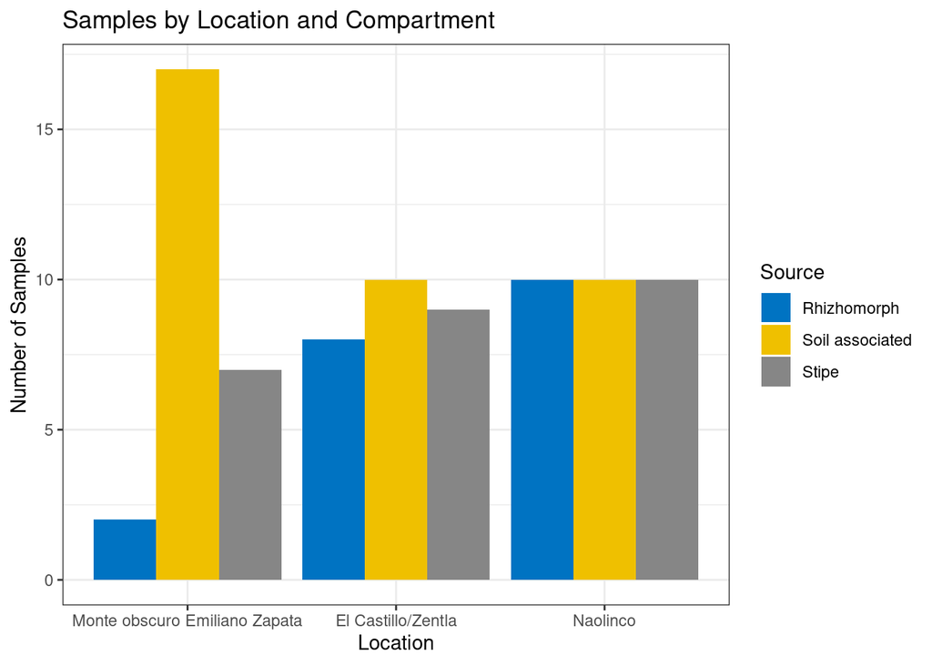

```r
# all
meta_all <- metadata_with_hill_all
all <- table(meta_all$Location, meta_all$Source)

table_df_all <- as.data.frame(all)
names(table_df_all) <- c("Location", "Source", "Count")

samples_plot_all <- ggplot(table_df_all, aes(x = Location, y = Count, fill = Source)) +
  geom_bar(stat="identity", position="dodge") +
  labs(title = "Samples by Location and Compartment", y = "Number of Samples") +
  theme_bw() + scale_color_jco() + scale_fill_jco()

samples_plot_all
```

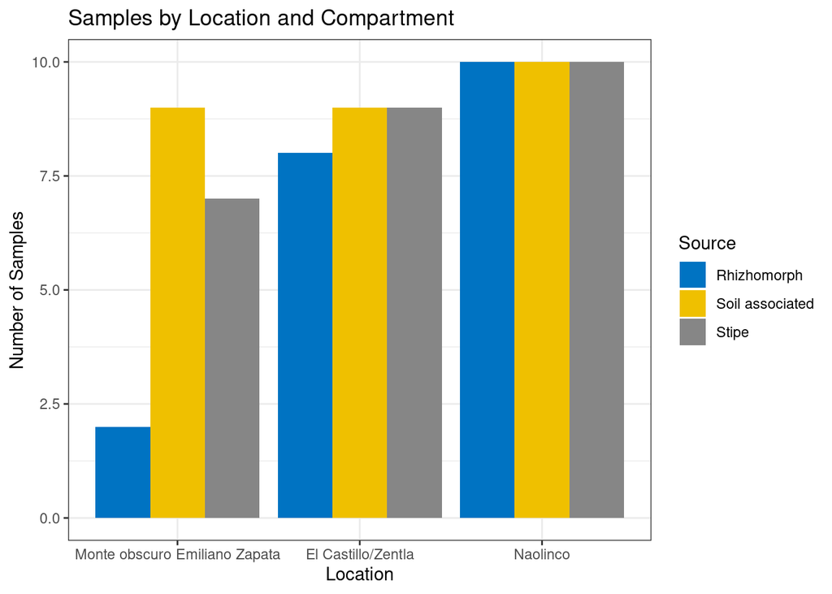

```r
# fltr

meta_fltr <- metadata_with_hill_fltr
fltr <- table(meta_fltr$Location, meta_fltr$Source)

table_df_fltr <- as.data.frame(fltr)
names(table_df_fltr) <- c("Location", "Source", "Count")

samples_plot_fltr <- ggplot(table_df_fltr, aes(x = Location, y = Count, fill = Source)) +
  geom_bar(stat="identity", position="dodge") +
  labs(title = "Samples by Location and Compartment", y = "Number of Samples") +
  theme_bw() + scale_color_jco() + scale_fill_jco()

samples_plot_fltr
```

### 9.3.1 Explore Hill distribution

Antes de declarar el modelo hay que darle formato categórico a los factores:

```r
metadata_with_hill_fltr$Compartment <- factor(
  metadata_with_hill_fltr$Source,
  levels = c(
    "Soil associated",
    "Rhizhomorph",
    "Stipe"
    ),
  labels = c(
    "Soil associated",
    "Rhizhomorph",
    "Stipe"
  )
)
metadata_with_hill_fltr$Location <- factor(
  metadata_with_hill_fltr$Location,
  levels = c("Monte obscuro Emiliano Zapata", "El Castillo/Zentla", "Naolinco"),
  labels = c("Monte obscuro Emiliano Zapata", "El Castillo/Zentla", "Naolinco")
  )
```

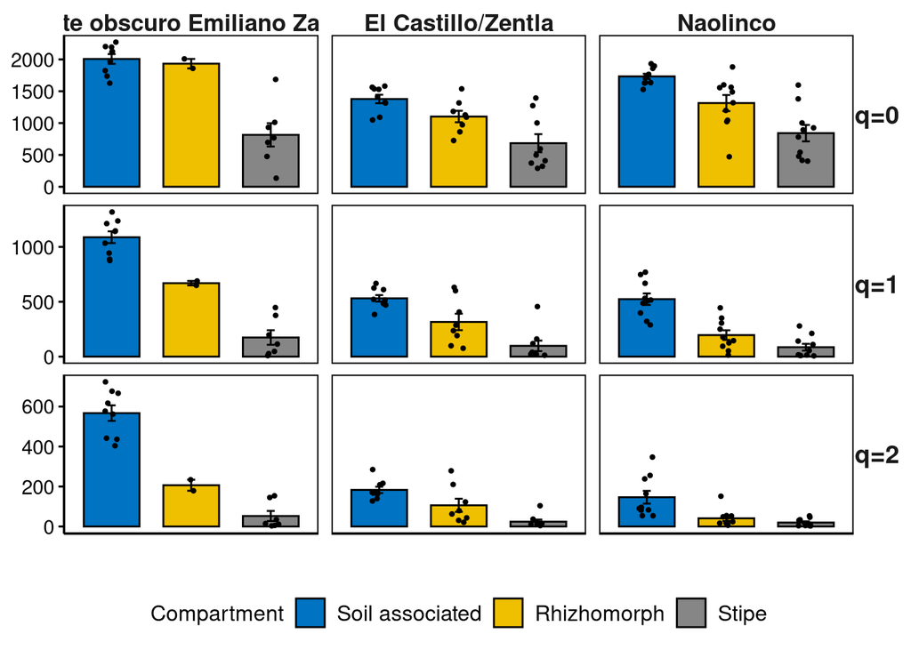

```r
library(ggpubr)

hill_barplot_explore_fltr <- metadata_with_hill_fltr %>%
  pivot_longer(cols = q0:q2, names_to = "q", values_to = "value") %>%
  filter(q %in% c("q0", "q1", "q2")) %>%
  mutate(
    qs = case_when(
      q == "q0" ~ "q=0",
      q == "q1" ~ "q=1",
      q == "q2" ~ "q=2"
    ),
    Location = factor(Location, levels = c("Monte obscuro Emiliano Zapata", "El Castillo/Zentla", "Naolinco"))
  ) %>%
  ggbarplot(
    x = "Compartment",
    y = "value",
    add = "mean_se",
    facet.by = c("qs", "Location"),
    fill = "Compartment"
  ) +
  scale_fill_jco() +
  geom_jitter(size = 0.8, position = position_jitter(width = 0.1)) +
  facet_grid(rows = vars(qs), cols = vars(Location), scales = "free_y") +
  theme(
    strip.background =  element_blank(), #element_rect(fill = "")
    strip.text.x = element_text(face= "bold", size = 13, margin = margin(0.5, 0, 0.5, 0)),
    strip.text.y = element_text(face= "bold", size = 14, angle = 0, margin = margin(0, 0.5, 0, 0.5)),
    axis.text.x = element_blank(),
    axis.ticks.x = element_blank(),
    axis.line = element_line(colour = "black"),
    #panel.border = element_blank(),
    panel.spacing.x = unit(0.5, "lines"),
    panel.background = element_blank(),
    axis.title.y = element_blank(),
    axis.text.y = element_text(colour = "black", size = 11),
    legend.position = "bottom"
  ) +
  labs(
    fill = "Compartment",
    y = "",
    x = "" #,
    #title = "Biodiversity across Locations and Compartments"
  ) + #+
  #theme(plot.title = element_text(hjust = 0.5))
   theme(legend.text = element_text(size = 12))

hill_barplot_explore_fltr
```

```r
ggsave("results/plots/02.diversity/02.fltr/01.Biodiversity_across_Locations and_Compartments_fltr.png", hill_barplot_explore_fltr, width = 11, height = 11)
```

### 9.3.2 Correlation Hill vs depth

**Alpha diversity depth correlation to order q=0**

```r
#install.packages("ggpubr")
library(ggpubr)

q0_vs_depth_fltr <- ggscatter(metadata_with_hill_fltr,
                         x = "Effective_reads",
                         y = "q0",
                         xlab= "Sequencing depth (number of reads)",
                         ylab = "q=0",
                         #ylab="Alpha diversity q=0 (effective number of total ASVs)",
   add = "reg.line",  # Add regression line
   add.params = list(color = "#114e9d", fill = "lightgray"), # Customize reg. line
   conf.int = TRUE, # Add confidence interval
   cor.coef = TRUE, # Add correlation coefficient. see ?stat_cor
   cor.coeff.args = list(method = "pearson", label.x = 3, label.sep = "\n")
   )+
  theme(legend.title = element_blank(), legend.position = "none")
```

**Alpha diversity depth correlation to order q=1**

```r
q1_vs_depth_fltr <- ggscatter(metadata_with_hill_fltr,
                         x = "Effective_reads",
                         y = "q1",
                         xlab= "Sequencing depth (number of reads)",
                         ylab = "q=1",
                         #ylab="Alpha diversity q=1 (effective number of total ASVs)",
   add = "reg.line",  # Add regression line
   add.params = list(color = "#114e9d", fill = "lightgray"), # Customize reg. line
   conf.int = TRUE, # Add confidence interval
   cor.coef = TRUE, # Add correlation coefficient. see ?stat_cor
   cor.coeff.args = list(method = "pearson", label.x = 3, label.sep = "\n")
   )+
  theme(legend.title = element_blank(), legend.position = "none")
```

**Alpha diversity depth correlation to order q=2**

```r
q2_vs_depth_fltr <- ggscatter(metadata_with_hill_fltr,
                         x = "Effective_reads",
                         y = "q2",
                         xlab= "Sequencing depth (number of reads)",
                         ylab = "q=2",
                         #ylab="Alpha diversity q=2 (effective number of total ASVs)",
   add = "reg.line",  # Add regression line
   add.params = list(color = "#114e9d", fill = "lightgray"), # Customize reg. line
   conf.int = TRUE, # Add confidence interval
   cor.coef = TRUE, # Add correlation coefficient. see ?stat_cor
   cor.coeff.args = list(method = "pearson", label.x = 3, label.sep = "\n")
   )+
  theme(legend.title = element_blank(), legend.position = "none")
```

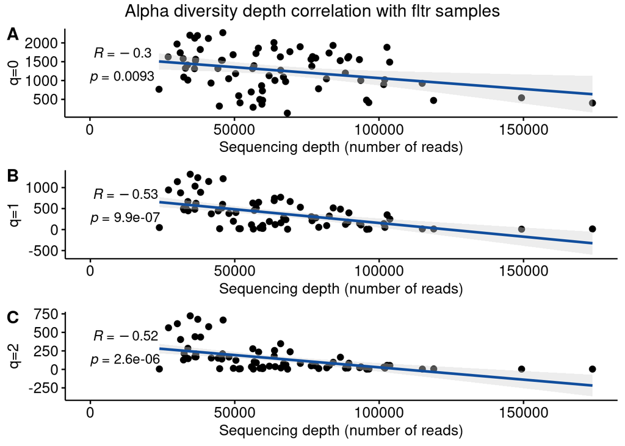

```r
library(ggplot2)
library(cowplot)

#save plots

#Combine plot
title_corr_plot <- ggdraw() + draw_label("Alpha diversity depth correlation with fltr samples")
correlation_plot_q012_fltr <- plot_grid(title_corr_plot, q0_vs_depth_fltr,q1_vs_depth_fltr,q2_vs_depth_fltr, labels = c(" ","A", "B", "C"), ncol = 1, rel_heights = c(0.15, 1, 1, 1))
correlation_plot_q012_fltr
```

```r
#save plot
ggsave("results/plots/02.diversity/02.fltr/02.alpha_depth_correlation_fltr_samples.png", correlation_plot_q012_fltr, width = 8, height = 8)
```

### 9.3.3 Shapiro test to Hill numbers

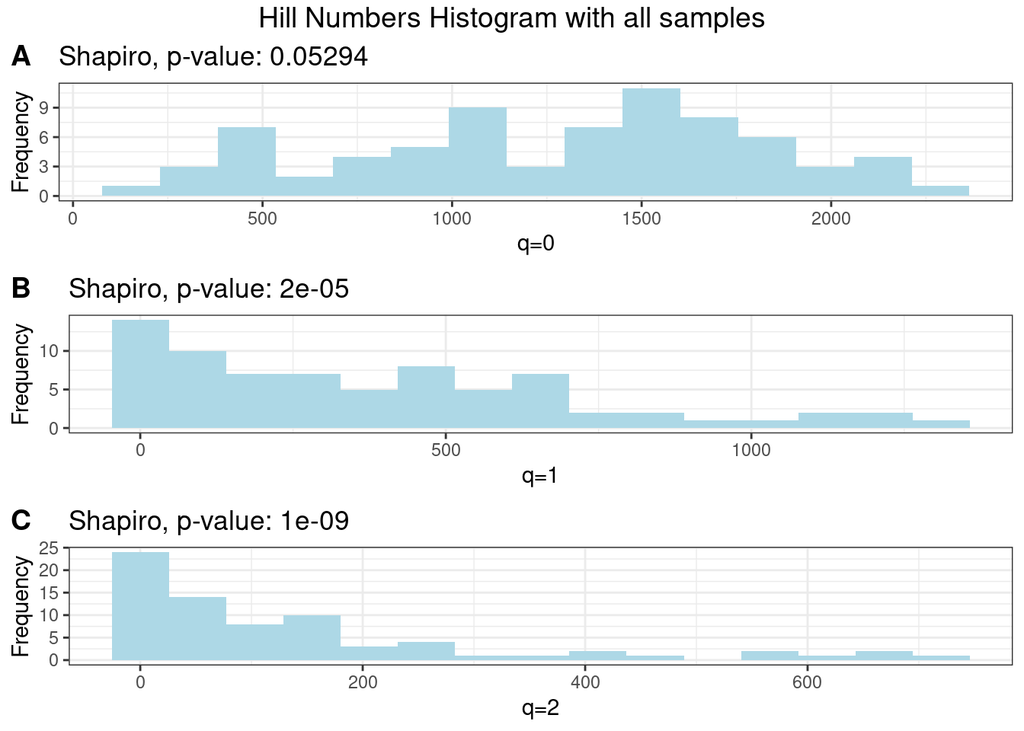

```r
library(ggplot2)
library(cowplot)

#Shapiro test
shapiro_q0_fltr <- shapiro.test(metadata_with_hill_fltr$q0)
shapiro_q0_fltr_pvalue <- round(shapiro_q0_fltr$p.value, 5)
shapiro_q1_fltr <- shapiro.test(metadata_with_hill_fltr$q1)
shapiro_q1_fltr_pvalue <- round(shapiro_q1_fltr$p.value, 5)
shapiro_q2_fltr <- shapiro.test(metadata_with_hill_fltr$q2)
shapiro_q2_fltr_pvalue <- round(shapiro_q2_fltr$p.value, 9)

#Histograms
histplot_q0_fltr <- ggplot(metadata_with_hill_fltr, aes(x = q0, xlab="q=0")) +
  geom_histogram(fill = "lightblue", bins = 15) +
  ggtitle(paste("Shapiro, p-value:", shapiro_q0_fltr_pvalue)) +
  theme_bw() + xlab("q=0") + ylab("Frequency")

histplot_q1_fltr <- ggplot(metadata_with_hill_fltr, aes(x = q1)) +
  geom_histogram(fill = "lightblue", bins = 15) +
  ggtitle(paste("Shapiro, p-value:", shapiro_q1_fltr_pvalue)) +
  theme_bw() + xlab("q=1") + ylab("Frequency")

histplot_q2_fltr <- ggplot(metadata_with_hill_fltr, aes(x = q2)) +
  geom_histogram(fill = "lightblue", bins = 15) +
  ggtitle(paste("Shapiro, p-value:", shapiro_q2_fltr_pvalue)) +
  theme_bw() + xlab("q=2") + ylab("Frequency")

#Combine plot
title_plot <- ggdraw() + draw_label("Hill Numbers Histogram with all samples") #, fontface = 'bold', x = 0.5, hjust = 0.5)
histplot_q012_fltr <- plot_grid(title_plot, histplot_q0_fltr, histplot_q1_fltr, histplot_q2_fltr, labels = c(" ","A", "B", "C"), ncol = 1, rel_heights = c(0.15, 1, 1, 1))
histplot_q012_fltr
```

```r
#save plot
ggsave("results/plots/02.diversity/02.fltr/03.hill_normality_test_histogram_fltr_samples.png", histplot_q012_fltr)
```

### 9.3.4 Linear Models

Es la implementación básica para realizar regresiones lineales y se usa principalmente cuando las observaciones son independientes y homogéneas en varianza

- Análisis de regresión simple y múltiple.
- Casos donde las observaciones no están agrupadas o anidadas.
- Situaciones donde no hay necesidad de modelar variabilidad aleatoria en los interceptos o pendientes más allá del término de error usual.

Ahora aplicar el test de normalidad a los residuales del modelo

**lm**

```r
#  Source and Location interaction

#q0
lm_q0_SL_fltr <-lm(q0 ~ log(Effective_reads)+Source*Location, data = metadata_with_hill_fltr)
Shap_lm_q0_SL_fltr <- shapiro.test(lm_q0_SL_fltr$residuals)

#q1
lm_q1_SL_fltr<-lm(q1 ~ log(Effective_reads)+Source*Location, data = metadata_with_hill_fltr)
Shap_lm_q1_SL_fltr <- shapiro.test(lm_q1_SL_fltr$residuals)

#q2
lm_q2_SL_fltr<-lm(q2 ~ log(Effective_reads)+Source*Location, data = metadata_with_hill_fltr)
Shap_lm_q2_SL_fltr <- shapiro.test(lm_q2_SL_fltr$residuals)

#  Source

#q0
lm_q0_S_fltr <-lm(q0 ~ log(Effective_reads)+Source, data = metadata_with_hill_fltr)
Shap_lm_q0_S_fltr <- shapiro.test(lm_q0_S_fltr$residuals)

#q1
lm_q1_S_fltr <-lm(q1 ~ log(Effective_reads)+Source, data = metadata_with_hill_fltr)
Shap_lm_q1_S_fltr <- shapiro.test(lm_q1_S_fltr$residuals)

#q2
lm_q2_S_fltr <-lm(q2 ~ log(Effective_reads)+Source, data = metadata_with_hill_fltr)
Shap_lm_q2_S_fltr <- shapiro.test(lm_q2_S_fltr$residuals)

#  Location

#q0
lm_q0_L_fltr <-lm(q0 ~ log(Effective_reads)+Location, data = metadata_with_hill_fltr)
Shap_lm_q0_L_fltr <- shapiro.test(lm_q0_L_fltr$residuals)

#q1
lm_q1_L_fltr <-lm(q1 ~ log(Effective_reads)+Location, data = metadata_with_hill_fltr)
Shap_lm_q1_L_fltr <- shapiro.test(lm_q1_L_all$residuals)

#q2
lm_q2_L_fltr <-lm(q2 ~ log(Effective_reads)+Location, data = metadata_with_hill_fltr)
Shap_lm_q2_L_fltr <- shapiro.test(lm_q2_L_fltr$residuals)
```

```r
library(dplyr)
library(knitr)
library(kableExtra)
# p-values
ShapVal_lm_q012_fltr <- tibble(
  Metric = c("q0", "q1", "q2"),
  `Source-Location Interaction` = c(Shap_lm_q0_SL_fltr$p.value, Shap_lm_q1_SL_fltr$p.value, Shap_lm_q2_SL_fltr$p.value),
  Source = c(Shap_lm_q0_S_fltr$p.value, Shap_lm_q1_S_fltr$p.value, Shap_lm_q2_S_fltr$p.value),
  Location = c(Shap_lm_q0_L_fltr$p.value, Shap_lm_q1_L_fltr$p.value, Shap_lm_q2_L_fltr$p.value)
)

# table
kable(ShapVal_lm_q012_fltr,
      col.names = c("Hill", "Source*Location", "Source", "Location"),
      caption = "Residuals Shapiro-Wilk p-values for each Efect (lm) fltr")
```

Residuals Shapiro-Wilk p-values for each Efect (lm) fltr

| Hill | Source*Location | Source | Location |
| --- | --- | --- | --- |
| q0 | 0.2611940 | 0.6701750 | 0.0445608 |
| q1 | 0.3693784 | 0.0425701 | 0.1299597 |
| q2 | 0.0107854 | 0.0005187 | 0.0004266 |

```r
# save
write.csv(ShapVal_lm_q012_fltr, "results/03.Diversity/Residuals_Shapiro-Wilk_p-values_each_Efect(lm)_fltr.csv", row.names = FALSE)
```

### 9.3.5 Linear Mixed Models

Estos modelos son útiles cuando las observaciones tienen estructuras de dependencia, como datos longitudinales o datos agrupados/anidados. Los modelos lineales mixtos incluyen tanto efectos fijos como efectos aleatorios, donde los efectos fijos son comunes a todas las unidades/individuos, y los efectos aleatorios varían por grupo o unidad.

**lme**

```r
#library(nlme)
# lme

# q0
q0_lme_fltr <- lme(q0 ~ log(Effective_reads)+Source*Location, random=~1 |Specimen, data = metadata_with_hill_fltr)
q0_lme_perm_fltr <- PermTest(q0_lme_fltr, B = 100)

# q1
q1_lme_fltr <- lme(q1 ~ log(Effective_reads)+Source*Location, random=~1 |Specimen, data = metadata_with_hill_fltr)
q1_lme_perm_fltr <- PermTest(q1_lme_fltr, B = 100)

# q2
q2_lme_fltr <- lme(q2 ~ log(Effective_reads)+Source*Location, random=~1 |Specimen, data = metadata_with_hill_fltr)
q2_lme_perm_fltr <- PermTest(q2_lme_fltr, B = 100)
```

```r
# extract p-values fun
extract_pvalues <- function(perm_test_result) {
  perm_test_result$resultats$p.value
}

# extract
lme_pvalues_q0_fltr <- extract_pvalues(q0_lme_perm_fltr)
lme_pvalues_q1_fltr <- extract_pvalues(q1_lme_perm_fltr)
lme_pvalues_q2_fltr <- extract_pvalues(q2_lme_perm_fltr)

# Dataframe  p-values
library(dplyr)

lme_pvalues_table_fltr <- data.frame(
  Hill = c("q0", "q1", "q2"),
  `Intercept` = c(lme_pvalues_q0_fltr[1], lme_pvalues_q1_fltr[1], lme_pvalues_q2_fltr[1]),
  `log(Depth)` = c(lme_pvalues_q0_fltr[2], lme_pvalues_q1_fltr[2], lme_pvalues_q2_fltr[2]),
  `Source` = c(lme_pvalues_q0_fltr[3], lme_pvalues_q1_fltr[3], lme_pvalues_q2_fltr[3]),
  `Location` = c(lme_pvalues_q0_fltr[4], lme_pvalues_q1_fltr[4], lme_pvalues_q2_fltr[4]),
  `Source:Location` = c(lme_pvalues_q0_fltr[5], lme_pvalues_q1_fltr[5], lme_pvalues_q2_fltr[5])
)

# table
knitr::kable(t(lme_pvalues_table_fltr), caption = "P-values from Permuted LME")
```

P-values from Permuted LME

| Hill | q0 | q1 | q2 |
| --- | --- | --- | --- |
| Intercept | 0.03 | 0.00 | 0.01 |
| log.Depth. | 0.19 | 0.00 | 0.01 |
| Source | 0 | 0 | 0 |
| Location | 0.01 | 0.00 | 0.06 |
| Source.Location | 0.03 | 0.00 | 0.00 |

```r
# save
write.csv(t(lme_pvalues_table_fltr), "results/03.Diversity/P-values_from_Permuted_LME_fltr.csv", row.names = FALSE)
```

### 9.3.6 Generalized Linear Mixed Models

Ahora con modelos generalizados:

**glm**

```r
summary(q0_glm_fltr)
```

```
##
## Call:
## glm(formula = q0 ~ log(Effective_reads) + Source * Location,
##     family = poisson(link = "log"), data = metadata_with_hill_fltr)
##
## Deviance Residuals:
##      Min        1Q    Median        3Q       Max
## -26.8165   -7.0138   -0.0708    4.6401   27.6387
##
## Coefficients:
##                                                  Estimate Std. Error z value
## (Intercept)                                      10.72223    0.18884  56.781
## log(Effective_reads)                             -0.28640    0.01708 -16.769
## SourceSoil associated                            -0.11955    0.02007  -5.958
## SourceStipe                                      -0.95400    0.02159 -44.190
## LocationEl Castillo/Zentla                       -0.57565    0.01931 -29.817
## LocationNaolinco                                 -0.28454    0.01921 -14.814
## SourceSoil associated:LocationEl Castillo/Zentla  0.21171    0.02259   9.370
## SourceStipe:LocationEl Castillo/Zentla            0.46776    0.02713  17.240
## SourceSoil associated:LocationNaolinco            0.35048    0.02224  15.760
## SourceStipe:LocationNaolinco                      0.55290    0.02643  20.920
##                                                  Pr(>|z|)
## (Intercept)                                       < 2e-16 ***
## log(Effective_reads)                              < 2e-16 ***
## SourceSoil associated                            2.56e-09 ***
## SourceStipe                                       < 2e-16 ***
## LocationEl Castillo/Zentla                        < 2e-16 ***
## LocationNaolinco                                  < 2e-16 ***
## SourceSoil associated:LocationEl Castillo/Zentla  < 2e-16 ***
## SourceStipe:LocationEl Castillo/Zentla            < 2e-16 ***
## SourceSoil associated:LocationNaolinco            < 2e-16 ***
## SourceStipe:LocationNaolinco                      < 2e-16 ***
## ---
## Signif. codes:  0 '***' 0.001 '**' 0.01 '*' 0.05 '.' 0.1 ' ' 1
##
## (Dispersion parameter for poisson family taken to be 1)
##
##     Null deviance: 19296.3  on 73  degrees of freedom
## Residual deviance:  7484.3  on 64  degrees of freedom
## AIC: 8159.5
##
## Number of Fisher Scoring iterations: 5
```

**glm quasipoisson**

```r
#q0 glm quasipoisson
q0_glm_quasipoisson_fltr <- glm(q0 ~ log(Effective_reads)+Source*Location,
              family = quasipoisson(link = "log"),
              data = metadata_with_hill_fltr)

#q1 glm quasipoisson
q1_glm_quasipoisson_fltr <- glm(q1 ~ log(Effective_reads)+Source*Location,
              family = quasipoisson(link = "log"),
              data = metadata_with_hill_fltr)

#q2 glm quasipoisson
q2_glm_quasipoisson_fltr <- glm(q1 ~ log(Effective_reads)+Source*Location,
              family = quasipoisson(link = "log"),
              data = metadata_with_hill_fltr)
```

```r
summary(q0_glm_quasipoisson_fltr)
```

```
##
## Call:
## glm(formula = q0 ~ log(Effective_reads) + Source * Location,
##     family = quasipoisson(link = "log"), data = metadata_with_hill_fltr)
##
## Deviance Residuals:
##      Min        1Q    Median        3Q       Max
## -26.8165   -7.0138   -0.0708    4.6401   27.6387
##
## Coefficients:
##                                                  Estimate Std. Error t value
## (Intercept)                                       10.7222     2.0482   5.235
## log(Effective_reads)                              -0.2864     0.1852  -1.546
## SourceSoil associated                             -0.1195     0.2176  -0.549
## SourceStipe                                       -0.9540     0.2342  -4.074
## LocationEl Castillo/Zentla                        -0.5757     0.2094  -2.749
## LocationNaolinco                                  -0.2845     0.2083  -1.366
## SourceSoil associated:LocationEl Castillo/Zentla   0.2117     0.2451   0.864
## SourceStipe:LocationEl Castillo/Zentla             0.4678     0.2943   1.589
## SourceSoil associated:LocationNaolinco             0.3505     0.2412   1.453
## SourceStipe:LocationNaolinco                       0.5529     0.2867   1.929
##                                                  Pr(>|t|)
## (Intercept)                                      1.95e-06 ***
## log(Effective_reads)                              0.12702
## SourceSoil associated                             0.58472
## SourceStipe                                       0.00013 ***
## LocationEl Castillo/Zentla                        0.00776 **
## LocationNaolinco                                  0.17677
## SourceSoil associated:LocationEl Castillo/Zentla  0.39087
## SourceStipe:LocationEl Castillo/Zentla            0.11688
## SourceSoil associated:LocationNaolinco            0.15110
## SourceStipe:LocationNaolinco                      0.05820 .
## ---
## Signif. codes:  0 '***' 0.001 '**' 0.01 '*' 0.05 '.' 0.1 ' ' 1
##
## (Dispersion parameter for quasipoisson family taken to be 117.6422)
##
##     Null deviance: 19296.3  on 73  degrees of freedom
## Residual deviance:  7484.3  on 64  degrees of freedom
## AIC: NA
##
## Number of Fisher Scoring iterations: 5
```

**glmer**

```r
#q0 glmer
q0_glmer_fltr <- glmer(q0 ~ log(Effective_reads)+Source*Location+(1|Specimen),
             family = poisson(link = "log"),
             data = metadata_with_hill_fltr)

#q1 glmer
q1_glmer_fltr <- glmer(q1 ~ log(Effective_reads)+Source*Location+(1|Specimen),
             family = poisson(link = "log"),
             data = metadata_with_hill_fltr)

#q2 glmer
q2_glmer_fltr <- glmer(q2 ~ log(Effective_reads)+Source*Location+(1|Specimen),
             family = poisson(link = "log"),
             data = metadata_with_hill_fltr)
```

```r
summary(q0_glmer_fltr)
```

```
## Generalized linear mixed model fit by maximum likelihood (Laplace
##   Approximation) [glmerMod]
##  Family: poisson  ( log )
## Formula: q0 ~ log(Effective_reads) + Source * Location + (1 | Specimen)
##    Data: metadata_with_hill_fltr
##
##      AIC      BIC   logLik deviance df.resid
##   5124.6   5149.9  -2551.3   5102.6       63
##
## Scaled residuals:
##      Min       1Q   Median       3Q      Max
## -18.7365  -4.9078   0.1221   4.2954  22.7950
##
## Random effects:
##  Groups   Name        Variance Std.Dev.
##  Specimen (Intercept) 0.03555  0.1885
## Number of obs: 74, groups:  Specimen, 27
##
## Fixed effects:
##                                                  Estimate Std. Error z value
## (Intercept)                                      10.37269    0.25952  39.968
## log(Effective_reads)                             -0.27228    0.02284 -11.921
## SourceSoil associated                             0.09670    0.02306   4.193
## SourceStipe                                      -0.80273    0.02410 -33.307
## LocationEl Castillo/Zentla                       -0.43640    0.09430  -4.628
## LocationNaolinco                                 -0.10923    0.09244  -1.182
## SourceSoil associated:LocationEl Castillo/Zentla  0.03155    0.02498   1.263
## SourceStipe:LocationEl Castillo/Zentla            0.35176    0.02939  11.970
## SourceSoil associated:LocationNaolinco            0.13666    0.02460   5.556
## SourceStipe:LocationNaolinco                      0.38963    0.02861  13.620
##                                                  Pr(>|z|)
## (Intercept)                                       < 2e-16 ***
## log(Effective_reads)                              < 2e-16 ***
## SourceSoil associated                            2.76e-05 ***
## SourceStipe                                       < 2e-16 ***
## LocationEl Castillo/Zentla                       3.69e-06 ***
## LocationNaolinco                                    0.237
## SourceSoil associated:LocationEl Castillo/Zentla    0.207
## SourceStipe:LocationEl Castillo/Zentla            < 2e-16 ***
## SourceSoil associated:LocationNaolinco           2.77e-08 ***
## SourceStipe:LocationNaolinco                      < 2e-16 ***
## ---
## Signif. codes:  0 '***' 0.001 '**' 0.01 '*' 0.05 '.' 0.1 ' ' 1
##
## Correlation of Fixed Effects:
##             (Intr) lg(E_) SrcSla SrcStp LcEC/Z LctnNl SSa:LC SS:LEC SSa:LN
## lg(Effctv_) -0.964
## SrcSlassctd -0.494  0.448
## SourceStipe -0.323  0.274  0.769
## LctnECstl/Z -0.197  0.000  0.171  0.161
## LocatinNlnc -0.099 -0.105  0.127  0.135  0.553
## SrcSa:LEC/Z  0.069 -0.012 -0.743 -0.600 -0.209 -0.160
## SrcSt:LEC/Z  0.268 -0.228 -0.632 -0.821 -0.175 -0.110  0.654
## SrcSassc:LN  0.324 -0.276 -0.873 -0.682 -0.160 -0.168  0.695  0.560
## SrcStp:LctN  0.362 -0.324 -0.690 -0.868 -0.136 -0.133  0.507  0.713  0.708
## optimizer (Nelder_Mead) convergence code: 0 (OK)
## Model failed to converge with max|grad| = 0.00745889 (tol = 0.002, component 1)
```

**glmmTMB**

```r
# glmmTMB
# q0
q0_glmmTMB_fltr <- glmmTMB(q0 ~ log(Effective_reads)+Source*Location + (1 | Specimen),
    family = poisson(link = "log"),
    data = metadata_with_hill_fltr,
    dispformula = ~ 1)  # Establecer la fórmula de la sobredispersión

# q1
q1_glmmTMB_fltr <- glmmTMB(q1 ~ log(Effective_reads)+Source*Location + (1 | Specimen),
    family = poisson(link = "log"),
    data = metadata_with_hill_fltr,
    dispformula = ~ 1)
# q2
q2_glmmTMB_fltr <- glmmTMB(q2 ~ log(Effective_reads)+Source*Location + (1 | Specimen),
    family = poisson(link = "log"),
    data = metadata_with_hill_fltr,
    dispformula = ~ 1)
summary(q0_glmmTMB_fltr)
```

```
##  Family: poisson  ( log )
## Formula:
## q0 ~ log(Effective_reads) + Source * Location + (1 | Specimen)
## Data: metadata_with_hill_fltr
##
##      AIC      BIC   logLik deviance df.resid
##   5124.6   5149.9  -2551.3   5102.6       63
##
## Random effects:
##
## Conditional model:
##  Groups   Name        Variance Std.Dev.
##  Specimen (Intercept) 0.03555  0.1885
## Number of obs: 74, groups:  Specimen, 27
##
## Conditional model:
##                                                  Estimate Std. Error z value
## (Intercept)                                      10.37266    0.25954   39.97
## log(Effective_reads)                             -0.27228    0.02284  -11.92
## SourceSoil associated                             0.09670    0.02307    4.19
## SourceStipe                                      -0.80273    0.02410  -33.30
## LocationEl Castillo/Zentla                       -0.43639    0.09430   -4.63
## LocationNaolinco                                 -0.10923    0.09244   -1.18
## SourceSoil associated:LocationEl Castillo/Zentla  0.03154    0.02498    1.26
## SourceStipe:LocationEl Castillo/Zentla            0.35176    0.02939   11.97
## SourceSoil associated:LocationNaolinco            0.13666    0.02460    5.56
## SourceStipe:LocationNaolinco                      0.38963    0.02861   13.62
##                                                  Pr(>|z|)
## (Intercept)                                       < 2e-16 ***
## log(Effective_reads)                              < 2e-16 ***
## SourceSoil associated                            2.76e-05 ***
## SourceStipe                                       < 2e-16 ***
## LocationEl Castillo/Zentla                       3.69e-06 ***
## LocationNaolinco                                    0.237
## SourceSoil associated:LocationEl Castillo/Zentla    0.207
## SourceStipe:LocationEl Castillo/Zentla            < 2e-16 ***
## SourceSoil associated:LocationNaolinco           2.77e-08 ***
## SourceStipe:LocationNaolinco                      < 2e-16 ***
## ---
## Signif. codes:  0 '***' 0.001 '**' 0.01 '*' 0.05 '.' 0.1 ' ' 1
```

**Verificar ajuste de varios modelos**

```r
calculate_AIC_quasiPoisson <- function(model) {
  residuals <- residuals(model, type = "pearson")
  deviance <- sum(residuals^2)
  n <- length(residuals)
  logLikelihood <- -0.5 * (n * log(2 * pi * deviance / n) + deviance)
  k <- length(coef(model))
  AIC_value <- 2 * k - 2 * logLikelihood
  return(AIC_value)
}
```

```r
calculate_AIC_quasiPoisson(q0_glm_quasipoisson_fltr)
```

```
## [1] 8027.169
```

```r
calculate_AIC_quasiPoisson(q1_glm_quasipoisson_fltr)
```

```
## [1] 6150.359
```

```r
calculate_AIC_quasiPoisson(q2_glm_quasipoisson_fltr)
```

```
## [1] 6150.359
```

```r
q012_gmodels_comparison_fltr <- data.frame(
  Model = c("GLM Poisson q0", "GLM Quasi-Poisson q0", "GLMM Poisson q0", "GLMM Poisson TMB q0",
            "GLM Poisson q1", "GLM Quasi-Poisson q1", "GLMM Poisson q1", "GLMM Poisson TMB q1",
            "GLM Poisson q2", "GLM Quasi-Poisson q2", "GLMM Poisson q2", "GLMM Poisson TMB q2"),
  AIC = c(AIC(q0_glm_fltr), calculate_AIC_quasiPoisson(q0_glm_quasipoisson_fltr), AIC(q0_glmer_fltr), AIC(q0_glmmTMB_fltr),
          AIC(q1_glm_fltr), calculate_AIC_quasiPoisson(q1_glm_quasipoisson_fltr), AIC(q1_glmer_fltr), AIC(q1_glmmTMB_fltr),
          AIC(q2_glm_fltr), calculate_AIC_quasiPoisson(q2_glm_quasipoisson_fltr), AIC(q2_glmer_fltr), AIC(q2_glmmTMB_fltr)),
  BIC = c(BIC(q0_glm_fltr), BIC(q0_glm_quasipoisson_fltr), BIC(q0_glmer_fltr), BIC(q0_glmmTMB_fltr),
          BIC(q1_glm_fltr), BIC(q1_glm_quasipoisson_fltr), BIC(q1_glmer_fltr), BIC(q1_glmmTMB_fltr),
          BIC(q2_glm_fltr), BIC(q2_glm_quasipoisson_fltr), BIC(q2_glmer_fltr), BIC(q2_glmmTMB_fltr)),
  Null_Deviance = c(q0_glm_fltr$null.deviance, q0_glm_quasipoisson_fltr$null.deviance, NA, NA,
                    q1_glm_fltr$null.deviance, q1_glm_quasipoisson_fltr$null.deviance, NA, NA,
                    q2_glm_fltr$null.deviance, q2_glm_quasipoisson_fltr$null.deviance, NA, NA),
  Residual_Deviance = c(q0_glm_fltr$deviance, q0_glm_quasipoisson_fltr$deviance, summary(q0_glmer_fltr)$deviance, summary(q0_glmmTMB_fltr)$deviance,
                        q1_glm_fltr$deviance, q1_glm_quasipoisson_fltr$deviance, summary(q1_glmer_fltr)$deviance, summary(q1_glmmTMB_fltr)$deviance,
                        q2_glm_fltr$deviance, q2_glm_quasipoisson_fltr$deviance, summary(q2_glmer_fltr)$deviance, summary(q2_glmmTMB_fltr)$deviance)
)
# show
print(q012_gmodels_comparison_fltr)
```

```
##                   Model      AIC      BIC Null_Deviance Residual_Deviance
## 1        GLM Poisson q0 8159.516 8182.557      19296.33          7484.343
## 2  GLM Quasi-Poisson q0 8027.169       NA      19296.33          7484.343
## 3       GLMM Poisson q0 5124.557 5149.901            NA          5454.139
## 4   GLMM Poisson TMB q0 5124.557 5149.901            NA          5454.139
## 5        GLM Poisson q1      Inf      Inf      23358.08          2365.248
## 6  GLM Quasi-Poisson q1 6150.359       NA      23358.08          5454.139
## 7       GLMM Poisson q1      Inf      Inf            NA          7484.343
## 8   GLMM Poisson TMB q1 3375.851 3401.196            NA          7484.343
## 9        GLM Poisson q2      Inf      Inf      13852.57          5454.139
## 10 GLM Quasi-Poisson q2 6150.359       NA      23358.08          5454.139
## 11      GLMM Poisson q2      Inf      Inf            NA          2365.248
## 12  GLMM Poisson TMB q2 1534.220 1559.565            NA          5454.139
```

```r
library(MuMIn)
library(kableExtra)

# Compare models
q012_model_selection_fltr <- model.sel(q0_glm_fltr, q0_glm_quasipoisson_fltr,
                                    q0_glmer_fltr, q0_glmmTMB_fltr,
                                    q1_glm_fltr, q1_glm_quasipoisson_fltr,
                                    q1_glmer_fltr, q1_glmmTMB_fltr,
                                    q2_glm_fltr, q2_glm_quasipoisson_fltr,
                                    q2_glmer_fltr, q2_glmmTMB_fltr)
# table
kable(q012_model_selection_fltr, format = "html") %>%
  kable_styling(bootstrap_options = c("striped", "hover"))
```

Location

log(Effective_reads)

Source

Location:Source

cond((Int))

disp((Int))

cond(Location)

cond(log(Effective_reads))

cond(Source)

cond(Location:Source)

family

class

df

logLik

AICc

delta

weight

q2_glmmTMB_fltr

NA

NA

NA

NA

NA

22.34323

-1.5440376

poisson(log)

glmmTMB

11

-756.1099

1538.478

0.000

NA

q1_glmmTMB_fltr

NA

NA

NA

NA

NA

19.36452

-1.1741671

poisson(log)

glmmTMB

11

-1676.9256

3380.109

1841.631

NA

q0_glmmTMB_fltr

NA

NA

NA

NA

NA

10.37266

-0.2722761

poisson(log)

glmmTMB

11

-2551.2783

5128.815

3590.337

NA

q0_glmer_fltr

10.37269

-0.2722777

NA

NA

NA

NA

NA

NA

poisson(log)

glmerMod

11

-2551.2783

5128.815

3590.337

NA

q0_glm_fltr

10.72223

-0.2863953

NA

NA

NA

NA

NA

NA

poisson(log)

glm

10

-4069.7582

8163.008

6624.530

NA

q1_glm_fltr

15.51086

-0.8173703

NA

NA

NA

NA

NA

NA

poisson(log)

glm

10

-Inf

Inf

Inf

NA

q1_glmer_fltr

19.39671

-1.1771272

NA

NA

NA

NA

NA

NA

poisson(log)

glmerMod

11

-Inf

Inf

Inf

NA

q2_glm_fltr

15.11464

-0.8882284

NA

NA

NA

NA

NA

NA

poisson(log)

glm

10

-Inf

Inf

Inf

NA

q2_glmer_fltr

22.42652

-1.5515652

NA

NA

NA

NA

NA

NA

poisson(log)

glmerMod

11

-Inf

Inf

Inf

NA

q0_glm_quasipoisson_fltr

10.72223

-0.2863953

NA

NA

NA

NA

NA

NA

quasipoisson(log)

glm

10

NA

NA

NA

NA

q1_glm_quasipoisson_fltr

15.51086

-0.8173703

NA

NA

NA

NA

NA

NA

quasipoisson(log)

glm

10

NA

NA

NA

NA

q2_glm_quasipoisson_fltr

15.51086

-0.8173703

NA

NA

NA

NA

NA

NA

quasipoisson(log)

glm

10

NA

NA

NA

NA

```r
summary(q0_glmmTMB_fltr)
```

```
##  Family: poisson  ( log )
## Formula:
## q0 ~ log(Effective_reads) + Source * Location + (1 | Specimen)
## Data: metadata_with_hill_fltr
##
##      AIC      BIC   logLik deviance df.resid
##   5124.6   5149.9  -2551.3   5102.6       63
##
## Random effects:
##
## Conditional model:
##  Groups   Name        Variance Std.Dev.
##  Specimen (Intercept) 0.03555  0.1885
## Number of obs: 74, groups:  Specimen, 27
##
## Conditional model:
##                                                  Estimate Std. Error z value
## (Intercept)                                      10.37266    0.25954   39.97
## log(Effective_reads)                             -0.27228    0.02284  -11.92
## SourceSoil associated                             0.09670    0.02307    4.19
## SourceStipe                                      -0.80273    0.02410  -33.30
## LocationEl Castillo/Zentla                       -0.43639    0.09430   -4.63
## LocationNaolinco                                 -0.10923    0.09244   -1.18
## SourceSoil associated:LocationEl Castillo/Zentla  0.03154    0.02498    1.26
## SourceStipe:LocationEl Castillo/Zentla            0.35176    0.02939   11.97
## SourceSoil associated:LocationNaolinco            0.13666    0.02460    5.56
## SourceStipe:LocationNaolinco                      0.38963    0.02861   13.62
##                                                  Pr(>|z|)
## (Intercept)                                       < 2e-16 ***
## log(Effective_reads)                              < 2e-16 ***
## SourceSoil associated                            2.76e-05 ***
## SourceStipe                                       < 2e-16 ***
## LocationEl Castillo/Zentla                       3.69e-06 ***
## LocationNaolinco                                    0.237
## SourceSoil associated:LocationEl Castillo/Zentla    0.207
## SourceStipe:LocationEl Castillo/Zentla            < 2e-16 ***
## SourceSoil associated:LocationNaolinco           2.77e-08 ***
## SourceStipe:LocationNaolinco                      < 2e-16 ***
## ---
## Signif. codes:  0 '***' 0.001 '**' 0.01 '*' 0.05 '.' 0.1 ' ' 1
```

```r
summary(q1_glmmTMB_fltr)
```

```
##  Family: poisson  ( log )
## Formula:
## q1 ~ log(Effective_reads) + Source * Location + (1 | Specimen)
## Data: metadata_with_hill_fltr
##
##      AIC      BIC   logLik deviance df.resid
##   3375.9   3401.2  -1676.9   3353.9       63
##
## Random effects:
##
## Conditional model:
##  Groups   Name        Variance Std.Dev.
##  Specimen (Intercept) 0.1081   0.3288
## Number of obs: 74, groups:  Specimen, 27
##
## Conditional model:
##                                                  Estimate Std. Error z value
## (Intercept)                                      19.36452    0.56711   34.15
## log(Effective_reads)                             -1.17417    0.05052  -23.24
## SourceSoil associated                            -0.05008    0.04156   -1.20
## SourceStipe                                      -1.77027    0.04800  -36.88
## LocationEl Castillo/Zentla                       -0.85414    0.16434   -5.20
## LocationNaolinco                                 -0.86433    0.16181   -5.34
## SourceSoil associated:LocationEl Castillo/Zentla  0.08380    0.04212    1.99
## SourceStipe:LocationEl Castillo/Zentla            0.63598    0.06225   10.22
## SourceSoil associated:LocationNaolinco            0.91691    0.04771   19.22
## SourceStipe:LocationNaolinco                      1.11194    0.06571   16.92
##                                                  Pr(>|z|)
## (Intercept)                                       < 2e-16 ***
## log(Effective_reads)                              < 2e-16 ***
## SourceSoil associated                              0.2282
## SourceStipe                                       < 2e-16 ***
## LocationEl Castillo/Zentla                       2.02e-07 ***
## LocationNaolinco                                 9.22e-08 ***
## SourceSoil associated:LocationEl Castillo/Zentla   0.0467 *
## SourceStipe:LocationEl Castillo/Zentla            < 2e-16 ***
## SourceSoil associated:LocationNaolinco            < 2e-16 ***
## SourceStipe:LocationNaolinco                      < 2e-16 ***
## ---
## Signif. codes:  0 '***' 0.001 '**' 0.01 '*' 0.05 '.' 0.1 ' ' 1
```

```r
summary(q2_glmmTMB_fltr)
```

```
##  Family: poisson  ( log )
## Formula:
## q2 ~ log(Effective_reads) + Source * Location + (1 | Specimen)
## Data: metadata_with_hill_fltr
##
##      AIC      BIC   logLik deviance df.resid
##   1534.2   1559.6   -756.1   1512.2       63
##
## Random effects:
##
## Conditional model:
##  Groups   Name        Variance Std.Dev.
##  Specimen (Intercept) 0.1662   0.4076
## Number of obs: 74, groups:  Specimen, 27
##
## Conditional model:
##                                                  Estimate Std. Error z value
## (Intercept)                                      22.34323    1.04255  21.431
## log(Effective_reads)                             -1.54404    0.09388 -16.447
## SourceSoil associated                             0.19418    0.07355   2.640
## SourceStipe                                      -2.05657    0.08843 -23.257
## LocationEl Castillo/Zentla                       -0.88148    0.20888  -4.220
## LocationNaolinco                                 -1.36539    0.20920  -6.527
## SourceSoil associated:LocationEl Castillo/Zentla -0.29695    0.07203  -4.122
## SourceStipe:LocationEl Castillo/Zentla            0.60090    0.11734   5.121
## SourceSoil associated:LocationNaolinco            0.98965    0.09258  10.690
## SourceStipe:LocationNaolinco                      1.62239    0.13249  12.245
##                                                  Pr(>|z|)
## (Intercept)                                       < 2e-16 ***
## log(Effective_reads)                              < 2e-16 ***
## SourceSoil associated                             0.00829 **
## SourceStipe                                       < 2e-16 ***
## LocationEl Castillo/Zentla                       2.44e-05 ***
## LocationNaolinco                                 6.72e-11 ***
## SourceSoil associated:LocationEl Castillo/Zentla 3.75e-05 ***
## SourceStipe:LocationEl Castillo/Zentla           3.04e-07 ***
## SourceSoil associated:LocationNaolinco            < 2e-16 ***
## SourceStipe:LocationNaolinco                      < 2e-16 ***
## ---
## Signif. codes:  0 '***' 0.001 '**' 0.01 '*' 0.05 '.' 0.1 ' ' 1
```

**Diagnóstico de residuos**

**Evaluar sobredispersion**

```r
#aún no entiendo para qué esto
drop1(q0_glmmTMB_fltr, test="Chisq")
```

|  | Df | AIC | LRT | Pr(>Chi) |
| --- | --- | --- | --- | --- |
|  | NA | 5124.557 | NA | NA |
| log(Effective_reads) | 1 | 5264.018 | 141.4609 | 1.275711e-32 |
| Source:Location | 4 | 5404.728 | 288.1715 | 3.854610e-61 |

Checar que onda con esto:

```r
#q0
alpha<- metadata_with_hill %>% unite("interact", c("Source", "Location"), remove = F)

q0_lme<-lme(q0~ interact, random=~1 |Specimen, data = alpha)
q0_lme_means<-emmeans(q0_lme, pairwise ~ interact)
multcomp::cld(object = q0_lme_means$emmeans,
              Letters = letters)
```

|  | interact | emmean | SE | df | lower.CL | upper.CL | .group |
| --- | --- | --- | --- | --- | --- | --- | --- |
| 7 | Stipe_El Castillo/Zentla | 679.9011 | 111.77120 | 35 | 452.9935 | 906.8087 | a |
| 8 | Stipe_Monte obscuro Emiliano Zapata | 731.4844 | 123.12443 | 35 | 481.5285 | 981.4403 | a |
| 9 | Stipe_Naolinco | 842.0000 | 106.66013 | 35 | 625.4684 | 1058.5316 | a |
| 1 | Rhizhomorph_El Castillo/Zentla | 1085.0017 | 117.46400 | 35 | 846.5371 | 1323.4663 | ab |
| 3 | Rhizhomorph_Naolinco | 1314.9000 | 106.66013 | 35 | 1098.3684 | 1531.4316 | b |
| 4 | Soil associated_El Castillo/Zentla | 1365.8000 | 106.66013 | 35 | 1149.2684 | 1582.3316 | bc |
| 6 | Soil associated_Naolinco | 1733.2000 | 106.66013 | 35 | 1516.6684 | 1949.7316 | cd |
| 2 | Rhizhomorph_Monte obscuro Emiliano Zapata | 1738.9221 | 220.71822 | 35 | 1290.8403 | 2187.0039 | bcd |
| 5 | Soil associated_Monte obscuro Emiliano Zapata | 1855.0683 | 83.05847 | 35 | 1686.4507 | 2023.6860 | d |

## 9.4 Diversity Compare, Summary

Number of samples

```r
dim(metadata_with_hill_all)
```

```
## [1] 83 17
```

```r
dim(metadata_with_hill_fltr)
```

```
## [1] 74 17
```

Distribution

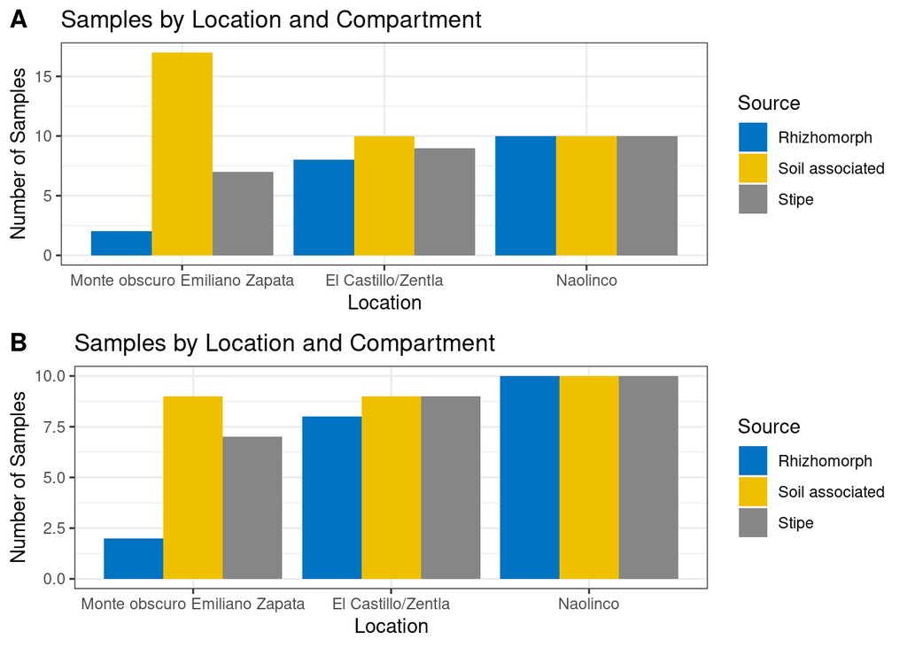

```r
plot_grid(samples_plot_all, samples_plot_fltr, labels = c("A", "B"), ncol = 1, rel_heights = c(1, 1))
```

Plot diversity

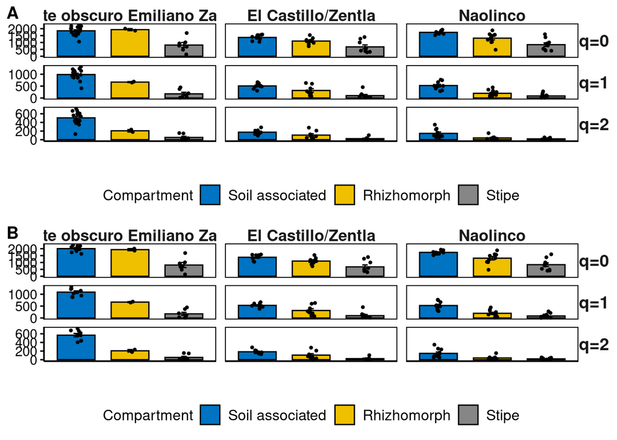

```r
plot_grid(hill_barplot_explore_all, hill_barplot_explore_fltr, labels = c("A", "B"), ncol = 1, rel_heights = c(1, 1))
```

Alpha correlation

[figure not shown]

```r
plot_grid(correlation_plot_q012_all, correlation_plot_q012_fltr, labels = c("A", "B"), ncol = 2, rel_heights = c(1, 1))
```

Histograms

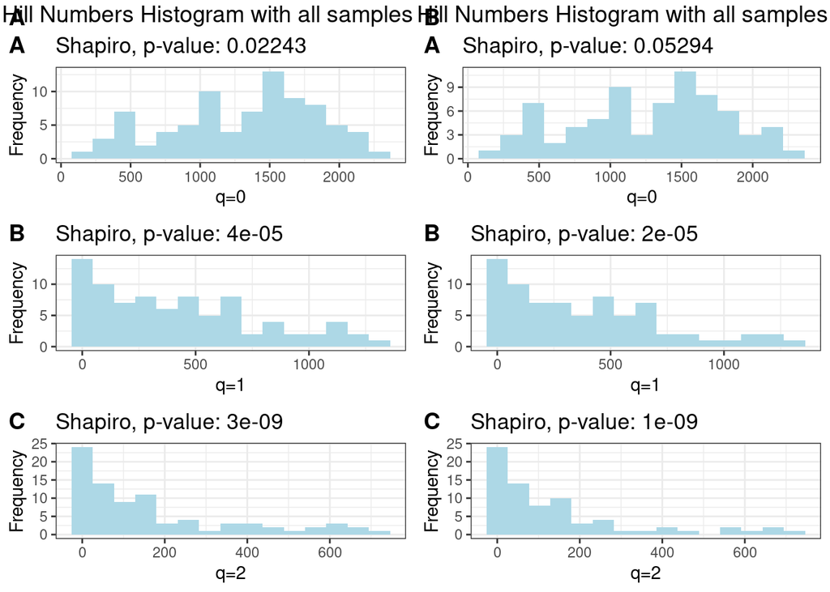

```r
plot_grid(histplot_q012_all, histplot_q012_fltr, labels = c("A", "B"), ncol = 2, rel_heights = c(1, 1))
```

Shapiro lm

```r
kable(ShapVal_lm_q012_all,
      col.names = c("Hill", "Source*Location", "Source", "Location"),
      caption = "Residuals Shapiro-Wilk p-values for each Efect (lm) all")
```

Residuals Shapiro-Wilk p-values for each Efect (lm) all

| Hill | Source*Location | Source | Location |
| --- | --- | --- | --- |
| q0 | 0.4498458 | 0.7877501 | 0.0270996 |
| q1 | 0.0088939 | 0.6262767 | 0.1299597 |
| q2 | 0.0000082 | 0.0568286 | 0.0008822 |

```r
kable(ShapVal_lm_q012_fltr,
      col.names = c("Hill", "Source*Location", "Source", "Location"),
      caption = "Residuals Shapiro-Wilk p-values for each Efect (lm) fltr")
```

Residuals Shapiro-Wilk p-values for each Efect (lm) fltr

| Hill | Source*Location | Source | Location |
| --- | --- | --- | --- |
| q0 | 0.2611940 | 0.6701750 | 0.0445608 |
| q1 | 0.3693784 | 0.0425701 | 0.1299597 |
| q2 | 0.0107854 | 0.0005187 | 0.0004266 |

Perm Test LME

```r
knitr::kable(t(lme_pvalues_table_all), caption = "P-values from Permuted LME all")
```

P-values from Permuted LME all

| Hill | q0 | q1 | q2 |
| --- | --- | --- | --- |
| Intercept | 0.18 | 0.00 | 0.02 |
| log.Depth. | 0.51 | 0.01 | 0.07 |
| Source | 0 | 0 | 0 |
| Location | 0.01 | 0.03 | 0.27 |
| Source.Location | 0.07 | 0.00 | 0.00 |

```r
knitr::kable(t(lme_pvalues_table_fltr), caption = "P-values from Permuted LME fltr")
```

P-values from Permuted LME fltr

| Hill | q0 | q1 | q2 |
| --- | --- | --- | --- |
| Intercept | 0.03 | 0.00 | 0.01 |
| log.Depth. | 0.19 | 0.00 | 0.01 |
| Source | 0 | 0 | 0 |
| Location | 0.01 | 0.00 | 0.06 |
| Source.Location | 0.03 | 0.00 | 0.00 |

AIC GLMM

```r
print(q012_gmodels_comparison_all)
```

```
##                   Model      AIC      BIC Null_Deviance Residual_Deviance
## 1        GLM Poisson q0 9152.852 9177.040      20581.63          8394.771
## 2  GLM Quasi-Poisson q0 8875.698       NA      20581.63          8394.771
## 3       GLMM Poisson q0 5261.055 5287.663            NA          6562.636
## 4   GLMM Poisson TMB q0 5261.055 5287.663            NA          6562.636
## 5        GLM Poisson q1      Inf      Inf      27024.62          3164.101
## 6  GLM Quasi-Poisson q1 7235.752       NA      27024.62          6562.636
## 7       GLMM Poisson q1      Inf      Inf            NA          8394.771
## 8   GLMM Poisson TMB q1 3510.944 3537.551            NA          8394.771
## 9        GLM Poisson q2      Inf      Inf      16988.36          6562.636
## 10 GLM Quasi-Poisson q2 7235.752       NA      27024.62          6562.636
## 11      GLMM Poisson q2      Inf      Inf            NA          3164.101
## 12  GLMM Poisson TMB q2 1661.927 1688.535            NA          6562.636
```

```r
print(q012_gmodels_comparison_fltr)
```

```
##                   Model      AIC      BIC Null_Deviance Residual_Deviance
## 1        GLM Poisson q0 8159.516 8182.557      19296.33          7484.343
## 2  GLM Quasi-Poisson q0 8027.169       NA      19296.33          7484.343
## 3       GLMM Poisson q0 5124.557 5149.901            NA          5454.139
## 4   GLMM Poisson TMB q0 5124.557 5149.901            NA          5454.139
## 5        GLM Poisson q1      Inf      Inf      23358.08          2365.248
## 6  GLM Quasi-Poisson q1 6150.359       NA      23358.08          5454.139
## 7       GLMM Poisson q1      Inf      Inf            NA          7484.343
## 8   GLMM Poisson TMB q1 3375.851 3401.196            NA          7484.343
## 9        GLM Poisson q2      Inf      Inf      13852.57          5454.139
## 10 GLM Quasi-Poisson q2 6150.359       NA      23358.08          5454.139
## 11      GLMM Poisson q2      Inf      Inf            NA          2365.248
## 12  GLMM Poisson TMB q2 1534.220 1559.565            NA          5454.139
```

```r
save.image("src/Diversity.RData")
```